# 🧬⚛️ Quantum-Inspired Genetic Algorithm pour la Détection d'Intrusions (IDS)

## Dataset : NSL-KDD | Sélection de Features par QIEA

## 🎯 Objectif du Notebook

Ce notebook présente une approche **innovante** de sélection de features pour un système de détection d'intrusions réseau (IDS).  
Au lieu d'utiliser toutes les colonnes du dataset, nous allons utiliser un **Algorithme Génétique Inspiré du Quantique (QIEA)** pour sélectionner automatiquement les **10 meilleures features**.

### 📋 Plan du Notebook :

1. **Théorie** : Qu'est-ce qu'un algorithme Quantique-Inspiré ?
2. **Préparation** : Chargement et prétraitement du dataset NSL-KDD
3. **QIEA** : Implémentation de l'algorithme de sélection de features
4. **Comparaison** : RandomForest sur toutes les features vs features QI-sélectionnées
5. **Résultats** : Analyse et visualisation

## 🧠 Théorie : Algorithme Génétique Inspiré du Quantique (QIEA)

### Qu'est-ce que le calcul quantique ?

En informatique classique, un **bit** vaut soit **0** soit **1**.  
En informatique quantique, un **qubit** (quantum bit) peut être dans une **superposition** des deux états simultanément :

$$|\psi\rangle = \alpha|0\rangle + \beta|1\rangle$$

où :

- $\alpha$ et $\beta$ sont des **amplitudes complexes** (nombres complexes)
- $|\alpha|^2$ = probabilité de mesurer **0** (feature NON sélectionnée)
- $|\beta|^2$ = probabilité de mesurer **1** (feature sélectionnée)
- La contrainte : $|\alpha|^2 + |\beta|^2 = 1$

### Comment le QIEA fonctionne pour la sélection de features ?

Chaque **feature** du dataset est représentée par un **qubit**.  
Le qubit encode la **probabilité** que cette feature soit incluse dans le sous-ensemble optimal.

**Cycle de l'algorithme :**

```
┌─────────────────────────────────────────────────────────┐
│  1. INITIALISATION                                       │
│     Chaque qubit commence à θ = π/4 (50/50)             │
│     → Probabilité égale d'inclure ou exclure une feature│
├─────────────────────────────────────────────────────────┤
│  2. OBSERVATION (Mesure quantique)                       │
│     On 'mesure' chaque qubit → obtient 0 ou 1           │
│     → Génère un chromosome binaire (masque de features)  │
├─────────────────────────────────────────────────────────┤
│  3. ÉVALUATION (Fitness)                                 │
│     Entraîne RandomForest sur les features sélectionnées│
│     → Score = accuracy du modèle                         │
├─────────────────────────────────────────────────────────┤
│  4. ROTATION QUANTIQUE (Mise à jour)                     │
│     Si feature dans meilleure solution → augmente P(1)  │
│     Si feature absente de meilleure solution → augmente P(0)│
├─────────────────────────────────────────────────────────┤
│  5. RÉPÉTER jusqu'à convergence                          │
└─────────────────────────────────────────────────────────┘
```

### La Rotation Quantique (cœur de l'algorithme)

La **Q-gate** (porte quantique de rotation) met à jour chaque angle $\theta_i$ :

$$\begin{pmatrix} \alpha_i' \\ \beta_i' \end{pmatrix} = \begin{pmatrix} \cos(\Delta\theta_i) & -\sin(\Delta\theta_i) \\ \sin(\Delta\theta_i) & \cos(\Delta\theta_i) \end{pmatrix} \begin{pmatrix} \alpha_i \\ \beta_i \end{pmatrix}$$

- $\Delta\theta_i$ est l'angle de rotation (typiquement 0.01π à 0.05π)
- La **direction** de rotation dépend de si la feature améliore ou nuit au fitness
- Au fil des générations, les angles **convergent** vers 0 ou π/2

### Avantage sur les Algorithmes Génétiques Classiques

| Aspect | AG Classique | QIEA |
| --- | --- | --- |
| Représentation | Bits fixes (0 ou 1) | Probabilités continues (qubits) |
| Exploration | Population large nécessaire | Efficace avec petite population |
| Convergence | Peut être lente | Plus rapide grâce à la superposition |
| Diversité | Risque de convergence prématurée | Maintenue par les amplitudes |

## 📦 Cellule 1 : Importation des Bibliothèques

On importe toutes les bibliothèques nécessaires. Pas besoin d'un vrai ordinateur quantique !  
Le QIEA est une **simulation classique** des principes quantiques.

```python
# ═══════════════════════════════════════════════════════════
# CELLULE 1 : Importation des bibliothèques
# ═══════════════════════════════════════════════════════════

import numpy as np
import pandas as pd
import matplotlib.pyplot as plt
import matplotlib.patches as mpatches
import seaborn as sns
import warnings
import time
from copy import deepcopy

# Machine Learning
from sklearn.ensemble import RandomForestClassifier
from sklearn.preprocessing import RobustScaler, LabelEncoder
from sklearn.model_selection import train_test_split, cross_val_score
from sklearn import metrics
from sklearn.metrics import (
    accuracy_score, precision_score, recall_score,
    f1_score, confusion_matrix, ConfusionMatrixDisplay,
    classification_report
)

warnings.filterwarnings('ignore')
np.random.seed(42)

# Style des graphiques
plt.style.use('seaborn-v0_8-darkgrid')
COLORS = {
    'quantum': '#6C63FF',   # violet pour QIEA
    'classic': '#FF6584',   # rouge pour classique
    'accent': '#43E97B',    # vert pour les highlights
    'dark': '#2D3436',      # texte sombre
    'light': '#F8F9FA'      # fond clair
}

print('✅ Bibliothèques importées avec succès !')
print(f'   NumPy version    : {np.__version__}')
print(f'   Pandas version   : {pd.__version__}')
print(f'   Scikit-learn     : importé')
```

```
✅ Bibliothèques importées avec succès !
   NumPy version    : 1.26.4
   Pandas version   : 2.2.3
   Scikit-learn     : importé
```

## 📂 Cellule 2 : Chargement du Dataset NSL-KDD

Le **NSL-KDD** est le dataset de référence pour les IDS.  
Il contient du trafic réseau normal et des attaques de différentes catégories :

- **DoS** : Denial of Service (ex: neptune, smurf)
- **Probe** : Surveillance et scanning (ex: portsweep)
- **R2L** : Remote-to-Local (ex: ftp_write)
- **U2R** : User-to-Root (ex: buffer_overflow)

**Pourquoi NSL-KDD plutôt que KDD'99 ?**

- Supprime les enregistrements dupliqués
- Plus équilibré entre train et test
- Référence académique standard

```python
# ═══════════════════════════════════════════════════════════
# CELLULE 2 : Chargement du Dataset NSL-KDD
# ═══════════════════════════════════════════════════════════

# Noms des colonnes (le dataset n'a pas d'en-tête)
COLUMNS = [
    'duration', 'protocol_type', 'service', 'flag',
    'src_bytes', 'dst_bytes', 'land', 'wrong_fragment', 'urgent', 'hot',
    'num_failed_logins', 'logged_in', 'num_compromised', 'root_shell',
    'su_attempted', 'num_root', 'num_file_creations', 'num_shells',
    'num_access_files', 'num_outbound_cmds', 'is_host_login', 'is_guest_login',
    'count', 'srv_count', 'serror_rate', 'srv_serror_rate', 'rerror_rate',
    'srv_rerror_rate', 'same_srv_rate', 'diff_srv_rate', 'srv_diff_host_rate',
    'dst_host_count', 'dst_host_srv_count', 'dst_host_same_srv_rate',
    'dst_host_diff_srv_rate', 'dst_host_same_src_port_rate',
    'dst_host_srv_diff_host_rate', 'dst_host_serror_rate',
    'dst_host_srv_serror_rate', 'dst_host_rerror_rate',
    'dst_host_srv_rerror_rate', 'outcome', 'level'
]

# ─── Adapter le chemin selon votre environnement ───
# LOCAL (Windows) : remplacer par votre chemin
TRAIN_PATH = r'nsl-kdd/KDDTrain+.txt'
TEST_PATH  = r'nsl-kdd/KDDTest+.txt'

# Chargement
print('⏳ Chargement du dataset NSL-KDD...')
data_train = pd.read_csv(TRAIN_PATH, header=None, names=COLUMNS)
data_test  = pd.read_csv(TEST_PATH,  header=None, names=COLUMNS)

print(f'✅ Dataset chargé !')
print(f'   Train : {data_train.shape[0]:,} lignes × {data_train.shape[1]} colonnes')
print(f'   Test  : {data_test.shape[0]:,}  lignes × {data_test.shape[1]} colonnes')

print('\n📊 Aperçu des 3 premières lignes :')
data_train.head(3)
```

```
⏳ Chargement du dataset NSL-KDD...
✅ Dataset chargé !
   Train : 125,973 lignes × 43 colonnes
   Test  : 22,544  lignes × 43 colonnes

📊 Aperçu des 3 premières lignes :
```

|  | duration | protocol_type | service | flag | src_bytes | dst_bytes | land | wrong_fragment | urgent | hot | ... | dst_host_same_srv_rate | dst_host_diff_srv_rate | dst_host_same_src_port_rate | dst_host_srv_diff_host_rate | dst_host_serror_rate | dst_host_srv_serror_rate | dst_host_rerror_rate | dst_host_srv_rerror_rate | outcome | level |
| --- | --- | --- | --- | --- | --- | --- | --- | --- | --- | --- | --- | --- | --- | --- | --- | --- | --- | --- | --- | --- | --- |
| 0 | 0 | tcp | ftp_data | SF | 491 | 0 | 0 | 0 | 0 | 0 | ... | 0.17 | 0.03 | 0.17 | 0.0 | 0.0 | 0.0 | 0.05 | 0.0 | normal | 20 |
| 1 | 0 | udp | other | SF | 146 | 0 | 0 | 0 | 0 | 0 | ... | 0.00 | 0.60 | 0.88 | 0.0 | 0.0 | 0.0 | 0.00 | 0.0 | normal | 15 |
| 2 | 0 | tcp | private | S0 | 0 | 0 | 0 | 0 | 0 | 0 | ... | 0.10 | 0.05 | 0.00 | 0.0 | 1.0 | 1.0 | 0.00 | 0.0 | neptune | 19 |

3 rows × 43 columns

## 🔍 Cellule 3 : Exploration Rapide du Dataset

Avant de modéliser, on comprend la distribution des classes.  
C'est crucial car un dataset déséquilibré peut biaiser le modèle.

```
═══════════════════════════════════════════════════════
  EXPLORATION DU DATASET NSL-KDD
═══════════════════════════════════════════════════════

📌 Distribution des outcomes (types d'attaques) :
outcome
normal             67343
neptune            41214
satan               3633
ipsweep             3599
portsweep           2931
smurf               2646
nmap                1493
back                 956
teardrop             892
warezclient          890
pod                  201
guess_passwd          53
buffer_overflow       30
warezmaster           20
land                  18
imap                  11
rootkit               10
loadmodule             9
ftp_write              8
multihop               7
phf                    4
perl                   3
spy                    2

✅ Valeurs manquantes : 0 (aucune !)

📁 Features catégorielles : ['protocol_type', 'service', 'flag', 'outcome']
📁 Features numériques    : 39 colonnes
```

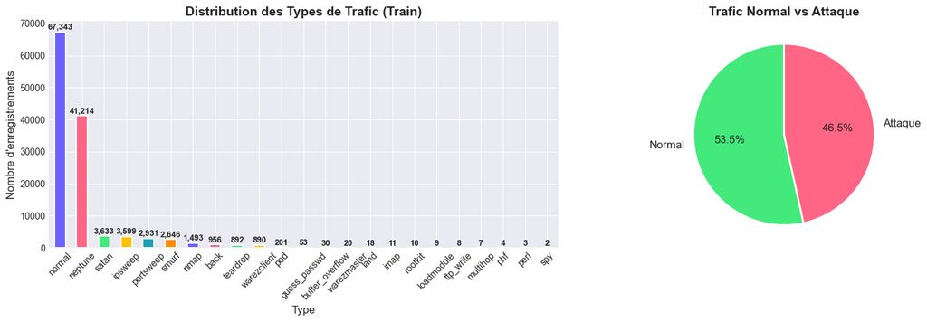

```
📊 Figure sauvegardée : 01_dataset_distribution.png
```

```python
# ═══════════════════════════════════════════════════════════
# CELLULE 3 : Exploration du Dataset
# ═══════════════════════════════════════════════════════════

print('═' * 55)
print('  EXPLORATION DU DATASET NSL-KDD')
print('═' * 55)

# Distribution des types de trafic
print('\n📌 Distribution des outcomes (types d\'attaques) :')
outcome_counts = data_train['outcome'].value_counts()
print(outcome_counts.to_string())

# Vérification des valeurs manquantes
missing = data_train.isnull().sum().sum()
print(f'\n✅ Valeurs manquantes : {missing} (aucune !)')

# Types de données
cat_features = data_train.select_dtypes(include='object').columns.tolist()
num_features = data_train.select_dtypes(exclude='object').columns.tolist()
print(f'\n📁 Features catégorielles : {cat_features}')
print(f'📁 Features numériques    : {len(num_features)} colonnes')

# Visualisation
fig, axes = plt.subplots(1, 2, figsize=(16, 5))

# Graphe 1 : Distribution brute
colors_pie = ['#6C63FF', '#FF6584', '#43E97B', '#FFC107', '#17A2B8', '#FF8C00']
outcome_counts.plot(
    kind='bar', ax=axes[0],
    color=colors_pie[:len(outcome_counts)],
    edgecolor='white', linewidth=1.5
)
axes[0].set_title('Distribution des Types de Trafic (Train)', fontsize=14, fontweight='bold')
axes[0].set_xlabel('Type', fontsize=12)
axes[0].set_ylabel('Nombre d\'enregistrements', fontsize=12)
axes[0].tick_params(axis='x', rotation=45)
for bar in axes[0].patches:
    axes[0].text(
        bar.get_x() + bar.get_width()/2,
        bar.get_height() + 100,
        f'{int(bar.get_height()):,}',
        ha='center', va='bottom', fontsize=9, fontweight='bold'
    )

# Graphe 2 : Binaire (Normal vs Attack)
binary_counts = data_train['outcome'].apply(
    lambda x: 'Normal' if x == 'normal' else 'Attaque'
).value_counts()
binary_counts.plot(
    kind='pie', ax=axes[1],
    colors=['#43E97B', '#FF6584'],
    autopct='%1.1f%%', startangle=90,
    wedgeprops={'edgecolor': 'white', 'linewidth': 2},
    textprops={'fontsize': 12}
)
axes[1].set_title('Trafic Normal vs Attaque', fontsize=14, fontweight='bold')
axes[1].set_ylabel('')

plt.tight_layout()
plt.savefig('01_dataset_distribution.png', dpi=150, bbox_inches='tight')
plt.show()
print('\n📊 Figure sauvegardée : 01_dataset_distribution.png')
```

## ⚙️ Cellule 4 : Prétraitement des Données

### Étapes du prétraitement :

**1. Binarisation de la cible**  
On transforme le problème multi-classes en binaire :

- `normal` → **0** (trafic légitime)
- Tout autre → **1** (attaque)

**2. Encodage des variables catégorielles**  
Les colonnes textuelles (`protocol_type`, `service`, `flag`) sont converties en nombres via **LabelEncoder**.

**3. Normalisation (RobustScaler)**
Utilise la médiane et l'IQR (interquartile range) au lieu de la moyenne et l'écart-type. $$x_{scaled} = \frac{x - \text{median}(x)}{\text{IQR}(x)}$$ **Avantage** : Robuste aux **outliers** (très présents dans les données réseau !)

```python
# ═══════════════════════════════════════════════════════════
# CELLULE 4 : Prétraitement des Données
# ═══════════════════════════════════════════════════════════

def preprocess_nslkdd(df_train, df_test):
    """
    Prétraitement complet du dataset NSL-KDD.

    Étapes :
      1. Copie pour ne pas modifier l'original
      2. Binarisation de la cible (normal=0, attack=1)
      3. Encodage Label des variables catégorielles
      4. Suppression de la colonne 'level' (pas une feature)
      5. Normalisation RobustScaler

    Retourne : X_train, X_test, y_train, y_test, feature_names
    """
    print('⚙️  Prétraitement en cours...')

    train = df_train.copy()
    test  = df_test.copy()

    # ── Étape 1 : Binarisation de la cible ──────────────────
    # Toutes les attaques → 1, trafic normal → 0
    for df in [train, test]:
        df['outcome'] = df['outcome'].apply(
            lambda x: 0 if x == 'normal' else 1
        )
    print('   ✅ Étape 1 : Binarisation (normal=0, attack=1)')

    # ── Étape 2 : Encodage des variables catégorielles ───────
    # Les colonnes textuelles ne peuvent pas être utilisées
    # directement par les algorithmes ML
    cat_cols = ['protocol_type', 'service', 'flag']
    encoders = {}
    for col in cat_cols:
        le = LabelEncoder()
        # Fit sur la combinaison train+test pour éviter les labels inconnus
        combined = pd.concat([train[col], test[col]])
        le.fit(combined)
        train[col] = le.transform(train[col])
        test[col]  = le.transform(test[col])
        encoders[col] = le
    print('   ✅ Étape 2 : Encodage catégoriel (protocol, service, flag)')

    # ── Étape 3 : Séparation features / cible ───────────────
    # On supprime 'level' (sévérité) car c'est une info liée à la cible
    EXCLUDE = ['outcome', 'level']
    feature_names = [c for c in train.columns if c not in EXCLUDE]

    X_train = train[feature_names].values
    X_test  = test[feature_names].values
    y_train = train['outcome'].values
    y_test  = test['outcome'].values
    print(f'   ✅ Étape 3 : Séparation → {len(feature_names)} features')

    # ── Étape 4 : Normalisation RobustScaler ────────────────
    # Formule : x_scaled = (x - median) / IQR
    # Résistant aux outliers (très utiles pour données réseau)
    scaler = RobustScaler()
    X_train = scaler.fit_transform(X_train)  # Fit UNIQUEMENT sur train !
    X_test  = scaler.transform(X_test)       # Transform sur test
    print('   ✅ Étape 4 : Normalisation RobustScaler appliquée')

    return X_train, X_test, y_train, y_test, feature_names


# Appel de la fonction
X_train, X_test, y_train, y_test, FEATURE_NAMES = preprocess_nslkdd(
    data_train, data_test
)

print(f'\n📐 Dimensions finales :')
print(f'   X_train : {X_train.shape}')
print(f'   X_test  : {X_test.shape}')
print(f'   y_train : {y_train.shape} | Attaques={y_train.sum()} Normal={len(y_train)-y_train.sum()}')
print(f'   y_test  : {y_test.shape}  | Attaques={y_test.sum()} Normal={len(y_test)-y_test.sum()}')
print(f'   Nombre de features : {len(FEATURE_NAMES)}')
```

[output not shown]

## 🔴 Cellule 5 : Baseline — RandomForest sur TOUTES les Features

Avant d'appliquer le QIEA, on établit un **baseline** (référence) :  
un RandomForest entraîné sur les **41 features** complètes.

Ce résultat sera notre point de comparaison.  
On mesure aussi le **temps d'entraînement**, crucial pour les architectures microservices IoT.

### Pourquoi RandomForest ?

- Robuste au bruit et aux outliers
- Pas besoin de normalisation supplémentaire
- Fournit une mesure d'importance des features
- Résistant au surapprentissage grâce au bagging

```python
# ═══════════════════════════════════════════════════════════
# CELLULE 5 : Baseline — RandomForest sur toutes les features
# ═══════════════════════════════════════════════════════════

print('═' * 55)
print('  BASELINE : RandomForest — 41 Features Complètes')
print('═' * 55)

# ── Entraînement + mesure du temps ──────────────────────────
print('\n⏳ Entraînement du modèle baseline...')
t0 = time.perf_counter()

rf_baseline = RandomForestClassifier(
    n_estimators=100,   # 100 arbres dans la forêt
    max_depth=None,     # Arbres complets (non élagués)
    n_jobs=-1,          # Utilise tous les cœurs CPU
    random_state=42
)
rf_baseline.fit(X_train, y_train)

t_baseline_train = time.perf_counter() - t0
print(f'   ✅ Entraînement terminé en {t_baseline_train:.2f} secondes')

# ── Prédiction + mesure du temps d'inférence ────────────────
t1 = time.perf_counter()
y_pred_baseline = rf_baseline.predict(X_test)
t_baseline_infer = time.perf_counter() - t1

# ── Calcul des métriques ─────────────────────────────────────
acc_bl  = accuracy_score(y_test,  y_pred_baseline)
prec_bl = precision_score(y_test, y_pred_baseline)
rec_bl  = recall_score(y_test,    y_pred_baseline)
f1_bl   = f1_score(y_test,        y_pred_baseline)

print(f'\n📊 Résultats Baseline (41 features) :')
print(f'   Accuracy  : {acc_bl:.4f}  ({acc_bl*100:.2f}%)')
print(f'   Precision : {prec_bl:.4f}')
print(f'   Recall    : {rec_bl:.4f}')
print(f'   F1-Score  : {f1_bl:.4f}')
print(f'   Temps train   : {t_baseline_train:.3f}s')
print(f'   Temps inférence: {t_baseline_infer:.4f}s')

# Sauvegarde pour comparaison finale
RESULTS = {
    'Baseline (41 features)': {
        'accuracy': acc_bl, 'precision': prec_bl,
        'recall': rec_bl,   'f1': f1_bl,
        'train_time': t_baseline_train,
        'infer_time': t_baseline_infer,
        'n_features': X_train.shape[1]
    }
}
```

```
═══════════════════════════════════════════════════════
  BASELINE : RandomForest — 41 Features Complètes
═══════════════════════════════════════════════════════

⏳ Entraînement du modèle baseline...
   ✅ Entraînement terminé en 1.06 secondes

📊 Résultats Baseline (41 features) :
   Accuracy  : 0.7710  (77.10%)
   Precision : 0.9662
   Recall    : 0.6193
   F1-Score  : 0.7548
   Temps train   : 1.056s
   Temps inférence: 0.0406s
```

## ⚛️ Cellule 6 : Implémentation du QIEA

Voici le cœur du notebook : l'implémentation complète du **Quantum-Inspired Evolutionary Algorithm**.

### Architecture de la classe QIEA :

```
QIEA
├── __init__()          → Initialise les hyperparamètres
├── _init_qubits()      → Crée le registre quantique
├── _observe()          → Mesure les qubits → chromosome binaire
├── _fitness()          → Évalue le chromosome avec RandomForest
├── _rotate()           → Applique la Q-gate (rotation)
└── fit()               → Lance l'évolution complète
```

### Les angles θ (theta) — l'état quantique :

Chaque feature $i$ a un angle $\theta_i \in [0, \frac{\pi}{2}]$ :

- $\theta_i = \frac{\pi}{4}$ → **50%** de chance d'être sélectionnée (état initial)
- $\theta_i \approx 0$ → **0%** → feature **exclue** (converge vers 0)
- $\theta_i \approx \frac{\pi}{2}$ → **100%** → feature **incluse** (converge vers π/2)

La **probabilité de sélection** d'une feature : $$P(\text{feature}_i = 1) = \sin^2(\theta_i) = |\beta_i|^2$$

```python
# ═══════════════════════════════════════════════════════════
# CELLULE 6 : Implémentation du QIEA
# ═══════════════════════════════════════════════════════════

class QuantumInspiredFeatureSelector:
    """
    Quantum-Inspired Evolutionary Algorithm (QIEA) pour la
    sélection de features dans un contexte de détection d'intrusions.

    Principe :
    - Chaque feature est représentée par un qubit (angle θ)
    - L'observation du qubit génère 0 (exclure) ou 1 (inclure)
    - La rotation Q-gate ajuste les probabilités selon la performance
    - L'algorithme converge vers le sous-ensemble optimal

    Paramètres :
    -----------
    n_features_target : int
        Nombre de features à sélectionner (objectif)
    n_generations : int
        Nombre d'itérations de l'algorithme évolutionnaire
    population_size : int
        Nombre de solutions explorées par génération
    rotation_angle : float
        Amplitude maximale de la rotation Q-gate (en radians)
    n_estimators_eval : int
        Nombre d'arbres pour l'évaluation fitness (rapide)
    """

    def __init__(
        self,
        n_features_target: int = 10,
        n_generations: int = 30,
        population_size: int = 10,
        rotation_angle: float = 0.05 * np.pi,
        n_estimators_eval: int = 30,
        verbose: bool = True
    ):
        self.n_features_target  = n_features_target
        self.n_generations      = n_generations
        self.population_size    = population_size
        self.rotation_angle     = rotation_angle
        self.n_estimators_eval  = n_estimators_eval
        self.verbose            = verbose

        # Résultats (remplis après fit)
        self.best_features_mask = None  # Masque binaire des features
        self.best_fitness       = -np.inf
        self.fitness_history    = []    # Historique pour la visualisation
        self.theta_history      = []    # Évolution des angles quantiques
        self.n_features_total_  = None  # Nombre de features du dataset

    # ────────────────────────────────────────────────────────
    # MÉTHODE 1 : Initialisation du Registre Quantique
    # ────────────────────────────────────────────────────────
    def _init_qubits(self, n_features: int) -> np.ndarray:
        """
        Initialise les angles θ des qubits.

        À θ = π/4 :
          P(1) = sin²(π/4) = (√2/2)² = 0.5
          P(0) = cos²(π/4) = (√2/2)² = 0.5

        → Toutes les features ont 50% de chance d'être sélectionnées.
        C'est l'état de SUPERPOSITION maximale.
        """
        return np.full(n_features, np.pi / 4)

    # ────────────────────────────────────────────────────────
    # MÉTHODE 2 : Observation Quantique (Mesure)
    # ────────────────────────────────────────────────────────
    def _observe(self, theta: np.ndarray) -> np.ndarray:
        """
        Mesure le registre quantique → génère un chromosome binaire.

        Pour chaque feature i :
          - Tire un nombre aléatoire r ~ Uniform(0, 1)
          - Si r < sin²(θᵢ) → bit = 1 (feature sélectionnée)
          - Sinon           → bit = 0 (feature exclue)

        Formule : P(bit_i = 1) = sin²(θᵢ) = β²ᵢ

        Retourne un masque binaire de longueur n_features.
        """
        probabilities = np.sin(theta) ** 2
        chromosome = (np.random.rand(len(theta)) < probabilities).astype(int)
        return chromosome

    # ────────────────────────────────────────────────────────
    # MÉTHODE 3 : Fonction Fitness
    # ────────────────────────────────────────────────────────
    def _fitness(
        self,
        chromosome: np.ndarray,
        X_train: np.ndarray,
        y_train: np.ndarray,
        X_val: np.ndarray,
        y_val: np.ndarray
    ) -> float:
        """
        Évalue la qualité d'un sous-ensemble de features.

        Le score FITNESS = accuracy d'un RandomForest entraîné
        uniquement sur les features sélectionnées par le chromosome.

        Si le chromosome sélectionne TROP peu de features (<3),
        on retourne un fitness pénalisé de 0 pour éviter
        les solutions triviales (sous-ensemble vide).

        Args:
            chromosome : array binaire [0,1,0,1,...] de longueur n_features

        Retourne : float entre 0 et 1 (accuracy)
        """
        # Indices des features sélectionnées
        selected_idx = np.where(chromosome == 1)[0]

        # Pénalisation si trop peu de features sélectionnées
        if len(selected_idx) < 3:
            return 0.0

        # Entraînement rapide d'un mini-RandomForest
        clf = RandomForestClassifier(
            n_estimators=self.n_estimators_eval,
            max_depth=5,       # Limité pour la vitesse
            n_jobs=-1,
            random_state=42
        )
        clf.fit(X_train[:, selected_idx], y_train)

        # Accuracy sur le set de validation
        y_pred = clf.predict(X_val[:, selected_idx])
        return accuracy_score(y_val, y_pred)

    # ────────────────────────────────────────────────────────
    # MÉTHODE 4 : Rotation Quantique (Q-gate)
    # ────────────────────────────────────────────────────────
    def _rotate(
        self,
        theta: np.ndarray,
        current_chromosome: np.ndarray,
        best_chromosome: np.ndarray
    ) -> np.ndarray:
        """
        Applique la Q-gate (porte de rotation quantique).

        Règle de rotation pour chaque feature i :

        ┌─────────┬─────────┬─────────────────────────────────┐
        │ current │  best   │ Direction de rotation Δθᵢ       │
        │   bᵢ    │   bᵢ*   │                                 │
        ├─────────┼─────────┼─────────────────────────────────┤
        │    1    │    1    │ +Δθ (renforce l'inclusion)      │
        │    0    │    0    │ -Δθ (renforce l'exclusion)      │
        │    1    │    0    │ -Δθ (corrige vers exclusion)    │
        │    0    │    1    │ +Δθ (corrige vers inclusion)    │
        └─────────┴─────────┴─────────────────────────────────┘

        θᵢ_new = θᵢ + Δθᵢ × direction
        θᵢ_new est clampé dans [0.01, π/2 - 0.01]
        """
        new_theta = theta.copy()
```

```python
        for i in range(len(theta)):
            b_current = current_chromosome[i]
            b_best    = best_chromosome[i]

            # Calcul de la direction selon la table de rotation
            if b_current == 1 and b_best == 1:
                direction = +1  # Renforcer : cette feature est bonne
            elif b_current == 0 and b_best == 0:
                direction = -1  # Renforcer : cette feature est inutile
            elif b_current == 1 and b_best == 0:
                direction = -1  # Corriger : on a inclus une mauvaise feature
            else:  # b_current == 0 and b_best == 1
                direction = +1  # Corriger : on a exclu une bonne feature

            # Application de la rotation
            new_theta[i] = theta[i] + direction * self.rotation_angle

            # Clamping : θ doit rester dans [ε, π/2 - ε]
            new_theta[i] = np.clip(new_theta[i], 0.01, np.pi / 2 - 0.01)

        return new_theta

    # ────────────────────────────────────────────────────────
    # MÉTHODE 5 : Boucle Principale d'Évolution
    # ────────────────────────────────────────────────────────
    def fit(
        self,
        X_train: np.ndarray,
        y_train: np.ndarray,
        X_val: np.ndarray,
        y_val: np.ndarray,
        feature_names: list = None
    ) -> 'QuantumInspiredFeatureSelector':
        """
        Lance l'évolution quantique-inspirée.

        Algorithme complet :
        ─────────────────────────────────────────────────────
        INITIALISATION
          θ ← [π/4, π/4, ..., π/4]   ← superposition uniforme
          best_chromosome ← None
          best_fitness    ← -∞

        POUR chaque génération g = 1..G :
          POUR chaque individu k = 1..K :
            chromosome_k ← observe(θ)       ← mesure quantique
            fitness_k    ← evaluate(chromosome_k)

          best_k ← argmax(fitness_k)

          SI fitness[best_k] > best_fitness_global :
            best_fitness    ← fitness[best_k]
            best_chromosome ← chromosome_k

          POUR chaque individu k :
            θ ← Q_gate(θ, chromosome_k, best_chromosome)

        SÉLECTION FINALE :
          → Les n_features_target features avec P(1) la plus haute
        ─────────────────────────────────────────────────────
        """
        n_features = X_train.shape[1]
        self.n_features_total_ = n_features
        self.feature_names_    = feature_names or [f'f{i}' for i in range(n_features)]

        if self.verbose:
            print('═' * 60)
            print('  QUANTUM-INSPIRED EVOLUTIONARY ALGORITHM (QIEA)')
            print('  Sélection de Features pour IDS NSL-KDD')
            print('═' * 60)
            print(f'  Features totales      : {n_features}')
            print(f'  Features cibles       : {self.n_features_target}')
            print(f'  Générations           : {self.n_generations}')
            print(f'  Population / génération: {self.population_size}')
            print(f'  Angle de rotation     : {self.rotation_angle/np.pi:.3f}π rad')
            print('═' * 60)

        t_start = time.perf_counter()

        # ── INITIALISATION ──────────────────────────────────
        # θ commence à π/4 pour tous les qubits
        # → Probabilité 50/50 d'inclure chaque feature
        theta = self._init_qubits(n_features)

        best_chromosome = np.zeros(n_features, dtype=int)
        best_fitness    = -np.inf

        # ── BOUCLE ÉVOLUTIONNAIRE ────────────────────────────
        for gen in range(self.n_generations):
            gen_fitnesses    = []
            gen_chromosomes  = []

            # Évaluation de la population
            for _ in range(self.population_size):
                # 1. Observation : mesure stochastique du registre quantique
                chromosome = self._observe(theta)

                # 2. Force le nombre de features vers la cible
                #    (soft constraint : ajuste le chromosome si trop de features)
                n_selected = chromosome.sum()
                if n_selected > self.n_features_target * 1.5:
                    # Désactive aléatoirement quelques features excédentaires
                    on_indices = np.where(chromosome == 1)[0]
                    n_to_flip  = n_selected - self.n_features_target
                    flip_idx   = np.random.choice(on_indices, n_to_flip, replace=False)
                    chromosome[flip_idx] = 0

                # 3. Évaluation fitness
                fit = self._fitness(chromosome, X_train, y_train, X_val, y_val)
                gen_fitnesses.append(fit)
                gen_chromosomes.append(chromosome)

            # Meilleur individu de cette génération
            best_gen_idx = np.argmax(gen_fitnesses)
            best_gen_fit = gen_fitnesses[best_gen_idx]
            best_gen_chr = gen_chromosomes[best_gen_idx]

            # Mise à jour du meilleur global
            if best_gen_fit > best_fitness:
                best_fitness    = best_gen_fit
                best_chromosome = best_gen_chr.copy()

            # Mise à jour des angles quantiques (Q-gate)
            for chrom in gen_chromosomes:
                theta = self._rotate(theta, chrom, best_chromosome)

            # Historique
            self.fitness_history.append(best_fitness)
            self.theta_history.append(theta.copy())

            if self.verbose and (gen % 5 == 0 or gen == self.n_generations - 1):
                n_sel = best_chromosome.sum()
                avg_fit = np.mean(gen_fitnesses)
                print(f'  Génération {gen+1:3d}/{self.n_generations} | '
                      f'Best Fitness: {best_fitness:.4f} | '
                      f'Avg: {avg_fit:.4f} | '
                      f'Features: {n_sel}')

        # ── SÉLECTION FINALE ─────────────────────────────────
        # Après convergence, on sélectionne les n_features_target
        # features avec la plus haute probabilité sin²(θᵢ)
        final_probabilities = np.sin(theta) ** 2
        top_k_idx = np.argsort(final_probabilities)[-self.n_features_target:]
```

```python
        final_mask = np.zeros(n_features, dtype=int)
        final_mask[top_k_idx] = 1
        self.best_features_mask = final_mask
        self.best_fitness       = best_fitness
        self.final_probabilities = final_probabilities

        t_elapsed = time.perf_counter() - t_start

        if self.verbose:
            print('═' * 60)
            print(f'  ✅ QIEA terminé en {t_elapsed:.1f} secondes')
            print(f'  🏆 Meilleur fitness : {best_fitness:.4f}')
            sel_names = [self.feature_names_[i] for i in top_k_idx]
            print(f'  📌 Features sélectionnées :')
            for name, prob in zip(sel_names, final_probabilities[top_k_idx]):
                print(f'     • {name:<35} P={prob:.3f}')
            print('═' * 60)

        return self

    def get_selected_indices(self) -> np.ndarray:
        """Retourne les indices des features sélectionnées."""
        return np.where(self.best_features_mask == 1)[0]

    def get_selected_names(self) -> list:
        """Retourne les noms des features sélectionnées."""
        idx = self.get_selected_indices()
        return [self.feature_names_[i] for i in idx]


print('✅ Classe QuantumInspiredFeatureSelector définie avec succès !')
print('   → Prête à être instanciée en Cellule 7')
```

```
✅ Classe QuantumInspiredFeatureSelector définie avec succès !
   → Prête à être instanciée en Cellule 7
```

## 🚀 Cellule 7 : Lancement du QIEA

On instancie et on lance l'algorithme QIEA.  
Pour l'évaluation interne (fitness), on utilise une **validation croisée light** (split 80/20 interne).

### Hyperparamètres choisis :

| Paramètre | Valeur | Explication |
| --- | --- | --- |
| `n_features_target` | 10 | On veut les 10 meilleures features |
| `n_generations` | 30 | 30 cycles d'évolution |
| `population_size` | 10 | 10 solutions testées par génération |
| `rotation_angle` | 0.05π | Pas de rotation modéré pour la stabilité |
| `n_estimators_eval` | 30 | RF rapide pour l'évaluation interne |

```python
# ═══════════════════════════════════════════════════════════
# CELLULE 7 : Lancement du QIEA
# ═══════════════════════════════════════════════════════════

# Split interne pour l'évaluation fitness du QIEA
# On garde X_test intact pour la comparaison finale
X_tr_qiea, X_val_qiea, y_tr_qiea, y_val_qiea = train_test_split(
    X_train, y_train,
    test_size=0.2,
    random_state=42,
    stratify=y_train
)

print(f'📐 Split interne QIEA :')
print(f'   Train fitness  : {X_tr_qiea.shape}')
print(f'   Val fitness    : {X_val_qiea.shape}')
print()

# ── Instanciation du QIEA ────────────────────────────────────
qiea = QuantumInspiredFeatureSelector(
    n_features_target  = 10,        # Sélectionner 10 features
    n_generations      = 30,        # 30 générations d'évolution
    population_size    = 10,        # 10 individus par génération
    rotation_angle     = 0.05 * np.pi,  # Δθ = 9° de rotation
    n_estimators_eval  = 30,        # RF rapide pour fitness
    verbose            = True
)

# ── Lancement de l'évolution ──────────────────────────────────
t_qiea_start = time.perf_counter()
qiea.fit(
    X_tr_qiea, y_tr_qiea,
    X_val_qiea, y_val_qiea,
    feature_names=FEATURE_NAMES
)
t_qiea_total = time.perf_counter() - t_qiea_start

print(f'\n⏱️  Temps total QIEA : {t_qiea_total:.1f}s')

# Récupération des features sélectionnées
SELECTED_IDX   = qiea.get_selected_indices()
SELECTED_NAMES = qiea.get_selected_names()

print(f'\n🎯 {len(SELECTED_NAMES)} features sélectionnées par le QIEA :')
for i, name in enumerate(SELECTED_NAMES, 1):
    prob = qiea.final_probabilities[SELECTED_IDX[i-1]]
    print(f'   {i:2d}. {name:<35} | P(sélection) = {prob:.3f}')
```

```
📐 Split interne QIEA :
   Train fitness  : (100778, 41)
   Val fitness    : (25195, 41)

════════════════════════════════════════════════════════════
  QUANTUM-INSPIRED EVOLUTIONARY ALGORITHM (QIEA)
  Sélection de Features pour IDS NSL-KDD
════════════════════════════════════════════════════════════
  Features totales      : 41
  Features cibles       : 10
  Générations           : 30
  Population / génération: 10
  Angle de rotation     : 0.050π rad
════════════════════════════════════════════════════════════
  Génération   1/30 | Best Fitness: 0.9809 | Avg: 0.9549 | Features: 10
  Génération   6/30 | Best Fitness: 0.9809 | Avg: 0.9809 | Features: 10
  Génération  11/30 | Best Fitness: 0.9809 | Avg: 0.9809 | Features: 10
  Génération  16/30 | Best Fitness: 0.9809 | Avg: 0.9809 | Features: 10
  Génération  21/30 | Best Fitness: 0.9809 | Avg: 0.9809 | Features: 10
  Génération  26/30 | Best Fitness: 0.9809 | Avg: 0.9809 | Features: 10
  Génération  30/30 | Best Fitness: 0.9809 | Avg: 0.9809 | Features: 10
════════════════════════════════════════════════════════════
  ✅ QIEA terminé en 48.0 secondes
  🏆 Meilleur fitness : 0.9809
  📌 Features sélectionnées :
     • dst_host_srv_diff_host_rate         P=1.000
     • src_bytes                           P=1.000
     • diff_srv_rate                       P=1.000
     • land                                P=1.000
     • dst_host_count                      P=1.000
     • serror_rate                         P=1.000
     • srv_count                           P=1.000
     • num_root                            P=1.000
     • dst_bytes                           P=1.000
     • dst_host_srv_rerror_rate            P=1.000
════════════════════════════════════════════════════════════

⏱️  Temps total QIEA : 48.0s

🎯 10 features sélectionnées par le QIEA :
    1. src_bytes                           | P(sélection) = 1.000
    2. dst_bytes                           | P(sélection) = 1.000
    3. land                                | P(sélection) = 1.000
    4. num_root                            | P(sélection) = 1.000
    5. srv_count                           | P(sélection) = 1.000
    6. serror_rate                         | P(sélection) = 1.000
    7. diff_srv_rate                       | P(sélection) = 1.000
    8. dst_host_count                      | P(sélection) = 1.000
    9. dst_host_srv_diff_host_rate         | P(sélection) = 1.000
   10. dst_host_srv_rerror_rate            | P(sélection) = 1.000
```

## 📉 Cellule 8 : Visualisation de la Convergence du QIEA

On visualise comment l'algorithme a convergé au fil des générations.  
Un bon QIEA montre une **montée rapide** du fitness puis une **stabilisation**.

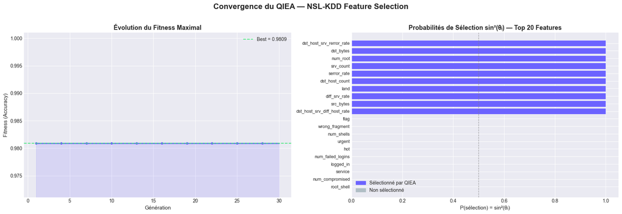

```
📊 Figure sauvegardée : 02_qiea_convergence.png
```

```python
# ═══════════════════════════════════════════════════════════
# CELLULE 8 : Visualisation de la Convergence du QIEA
# ═══════════════════════════════════════════════════════════

fig, axes = plt.subplots(1, 2, figsize=(18, 6))
fig.suptitle('Convergence du QIEA — NSL-KDD Feature Selection',
             fontsize=16, fontweight='bold', y=1.02)

# ── Graphe 1 : Courbe de Fitness ────────────────────────────
generations = range(1, len(qiea.fitness_history) + 1)
axes[0].plot(
    generations, qiea.fitness_history,
    color=COLORS['quantum'], linewidth=2.5,
    marker='o', markersize=4, markevery=3
)
axes[0].fill_between(
    generations, qiea.fitness_history,
    alpha=0.15, color=COLORS['quantum']
)
axes[0].axhline(
    y=qiea.best_fitness, color=COLORS['accent'],
    linestyle='--', linewidth=1.5, label=f'Best = {qiea.best_fitness:.4f}'
)
axes[0].set_title('Évolution du Fitness Maximal', fontsize=13, fontweight='bold')
axes[0].set_xlabel('Génération', fontsize=11)
axes[0].set_ylabel('Fitness (Accuracy)', fontsize=11)
axes[0].legend(fontsize=10)
axes[0].set_ylim([min(qiea.fitness_history) * 0.99, 1.001])

# ── Graphe 2 : Probabilités Finales des Features ────────────
probs = qiea.final_probabilities
sorted_idx = np.argsort(probs)[::-1]

# Top 20 features pour la lisibilité
TOP_N = min(20, len(FEATURE_NAMES))
top_idx    = sorted_idx[:TOP_N]
top_names  = [FEATURE_NAMES[i] for i in top_idx]
top_probs  = probs[top_idx]
bar_colors = [
    COLORS['quantum'] if i in SELECTED_IDX else '#B0BEC5'
    for i in top_idx
]

bars = axes[1].barh(
    range(TOP_N), top_probs[::-1],
    color=bar_colors[::-1], edgecolor='white', linewidth=0.5
)
axes[1].set_yticks(range(TOP_N))
axes[1].set_yticklabels(top_names[::-1], fontsize=9)
axes[1].axvline(x=0.5, color='gray', linestyle='--', linewidth=1, alpha=0.7,
                label='Seuil 50% (état initial)')
axes[1].set_title('Probabilités de Sélection sin²(θᵢ) — Top 20 Features',
                  fontsize=13, fontweight='bold')
axes[1].set_xlabel('P(sélection) = sin²(θᵢ)', fontsize=11)
axes[1].legend(fontsize=10)

# Légende couleurs
selected_patch = mpatches.Patch(color=COLORS['quantum'], label='Sélectionné par QIEA')
other_patch    = mpatches.Patch(color='#B0BEC5', label='Non sélectionné')
axes[1].legend(handles=[selected_patch, other_patch], fontsize=10)

plt.tight_layout()
plt.savefig('02_qiea_convergence.png', dpi=150, bbox_inches='tight')
plt.show()
print('📊 Figure sauvegardée : 02_qiea_convergence.png')
```

## 🟢 Cellule 9 : RandomForest avec les Features QIEA (10 features)

Maintenant on entraîne le modèle **final** uniquement sur les 10 features sélectionnées par le QIEA.  
Ce modèle est bien plus léger et adapté aux **architectures microservices IoT**.

```python
# ═══════════════════════════════════════════════════════════
# CELLULE 9 : RandomForest avec Features QIEA (10 features)
# ═══════════════════════════════════════════════════════════

print('═' * 55)
print('  MODÈLE QI : RandomForest — 10 Features QIEA')
print('═' * 55)

# Extraction des sous-ensembles de données
X_train_qi = X_train[:, SELECTED_IDX]  # Uniquement les 10 features
X_test_qi  = X_test[:, SELECTED_IDX]

print(f'   Features utilisées : {len(SELECTED_IDX)} (vs {X_train.shape[1]} baseline)')
print(f'   Réduction          : -{((1 - len(SELECTED_IDX)/X_train.shape[1])*100):.0f}% de features')

# ── Entraînement + mesure du temps ──────────────────────────
print('\n⏳ Entraînement du modèle QIEA...')
t0 = time.perf_counter()

rf_qi = RandomForestClassifier(
    n_estimators=100,
    max_depth=None,
    n_jobs=-1,
    random_state=42
)
rf_qi.fit(X_train_qi, y_train)

t_qi_train = time.perf_counter() - t0
print(f'   ✅ Entraînement terminé en {t_qi_train:.2f} secondes')

# ── Prédiction ──────────────────────────────────────────────
t1 = time.perf_counter()
y_pred_qi = rf_qi.predict(X_test_qi)
t_qi_infer = time.perf_counter() - t1

# ── Calcul des métriques ─────────────────────────────────────
acc_qi  = accuracy_score(y_test,  y_pred_qi)
prec_qi = precision_score(y_test, y_pred_qi)
rec_qi  = recall_score(y_test,    y_pred_qi)
f1_qi   = f1_score(y_test,        y_pred_qi)

print(f'\n📊 Résultats QIEA (10 features) :')
print(f'   Accuracy  : {acc_qi:.4f}  ({acc_qi*100:.2f}%)')
print(f'   Precision : {prec_qi:.4f}')
print(f'   Recall    : {rec_qi:.4f}')
print(f'   F1-Score  : {f1_qi:.4f}')
print(f'   Temps train    : {t_qi_train:.3f}s')
print(f'   Temps inférence: {t_qi_infer:.4f}s')

# Comparaison rapide
speed_ratio = t_baseline_train / t_qi_train
print(f'\n🚀 Accélération entraînement : ×{speed_ratio:.1f} plus rapide')
print(f'📈 Différence accuracy       : {(acc_qi - acc_bl)*100:+.3f}%')

# Sauvegarde
RESULTS['QIEA (10 features)'] = {
    'accuracy': acc_qi, 'precision': prec_qi,
    'recall': rec_qi,   'f1': f1_qi,
    'train_time': t_qi_train,
    'infer_time': t_qi_infer,
    'n_features': len(SELECTED_IDX)
}
```

```
═══════════════════════════════════════════════════════
  MODÈLE QI : RandomForest — 10 Features QIEA
═══════════════════════════════════════════════════════
   Features utilisées : 10 (vs 41 baseline)
   Réduction          : -76% de features

⏳ Entraînement du modèle QIEA...
   ✅ Entraînement terminé en 0.73 secondes

📊 Résultats QIEA (10 features) :
   Accuracy  : 0.7854  (78.54%)
   Precision : 0.9681
   Recall    : 0.6443
   F1-Score  : 0.7737
   Temps train    : 0.735s
   Temps inférence: 0.0281s

🚀 Accélération entraînement : ×1.4 plus rapide
📈 Différence accuracy       : +1.446%
```

## 📊 Cellule 10 : Matrices de Confusion Comparatives

La matrice de confusion montre en détail les types d'erreurs :

```
                Prédit Normal   Prédit Attaque
Réel Normal   │ True Negative  │ False Positive │
Réel Attaque  │ False Negative │ True Positive  │
```

- **FP (Fausse Alarme)** : Trafic normal classifié comme attaque → pénalisant pour les opérateurs
- **FN (Attaque manquée)** : Attaque non détectée → dangereux pour la sécurité !

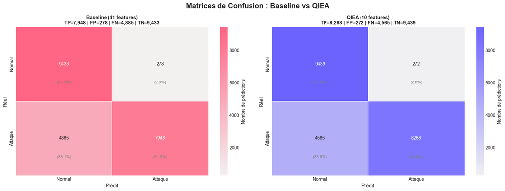

```
📊 Figure sauvegardée : 03_confusion_matrices.png
```

```python
# ═══════════════════════════════════════════════════════════
# CELLULE 10 : Matrices de Confusion Comparatives
# ═══════════════════════════════════════════════════════════

fig, axes = plt.subplots(1, 2, figsize=(16, 6))
fig.suptitle('Matrices de Confusion : Baseline vs QIEA',
             fontsize=16, fontweight='bold')

models_info = [
    (y_pred_baseline, 'Baseline (41 features)', COLORS['classic'], axes[0]),
    (y_pred_qi,       'QIEA (10 features)',     COLORS['quantum'], axes[1]),
]

for y_pred, title, color, ax in models_info:
    cm = confusion_matrix(y_test, y_pred)

    # Normalisation pour affichage en %
    cm_norm = cm.astype('float') / cm.sum(axis=1)[:, np.newaxis]

    sns.heatmap(
        cm, annot=True, fmt='d', ax=ax,
        cmap=sns.light_palette(color, as_cmap=True),
        xticklabels=['Normal', 'Attaque'],
        yticklabels=['Normal', 'Attaque'],
        linewidths=0.5, linecolor='white',
        cbar_kws={'label': 'Nombre de prédictions'}
    )

    # Ajout des pourcentages
    for i in range(2):
        for j in range(2):
            ax.text(j + 0.5, i + 0.75, f'({cm_norm[i,j]*100:.1f}%)',
                   ha='center', va='center', fontsize=9,
                   color='gray')

    tn, fp, fn, tp = cm.ravel()
    ax.set_title(title, fontsize=13, fontweight='bold', pad=10)
    ax.set_xlabel('Prédit', fontsize=11)
    ax.set_ylabel('Réel', fontsize=11)

    # Info dans le titre
    subtitle = f'TP={tp:,} | FP={fp:,} | FN={fn:,} | TN={tn:,}'
    ax.set_title(f'{title}\n{subtitle}', fontsize=11, fontweight='bold')

plt.tight_layout()
plt.savefig('03_confusion_matrices.png', dpi=150, bbox_inches='tight')
plt.show()
print('📊 Figure sauvegardée : 03_confusion_matrices.png')
```

## 🏆 Cellule 11 : Tableau Comparatif Final & Visualisations

Comparaison complète entre les deux approches sur toutes les dimensions :

- **Performance** : Accuracy, Precision, Recall, F1
- **Efficacité** : Temps d'entraînement, Temps d'inférence
- **Complexité** : Nombre de features utilisées

```python
# ═══════════════════════════════════════════════════════════
# CELLULE 11 : Tableau Comparatif Final
# ═══════════════════════════════════════════════════════════

# ── Tableau de comparaison ───────────────────────────────────
comparison_df = pd.DataFrame(RESULTS).T
comparison_df.columns = [
    'Accuracy', 'Precision', 'Recall', 'F1-Score',
    'Train Time (s)', 'Infer Time (s)', 'N Features'
]
comparison_df = comparison_df.round(4)

print('═' * 75)
print('  TABLEAU COMPARATIF FINAL : BASELINE vs QIEA')
print('═' * 75)
print(comparison_df.to_string())

# Calcul des gains
bl = RESULTS['Baseline (41 features)']
qi = RESULTS['QIEA (10 features)']

print('\n' + '═' * 55)
print('  ANALYSE DES GAINS')
print('═' * 55)

gain_acc     = (qi['accuracy'] - bl['accuracy']) * 100
gain_f1      = (qi['f1'] - bl['f1']) * 100
speedup_train = bl['train_time'] / qi['train_time']
speedup_infer = bl['infer_time'] / qi['infer_time']
feat_reduction = (1 - qi['n_features'] / bl['n_features']) * 100

print(f'  Réduction features   : {feat_reduction:.0f}% '
      f'({bl["n_features"]} → {qi["n_features"]} features)')
print(f'  Gain Accuracy        : {gain_acc:+.3f}%')
print(f'  Gain F1-Score        : {gain_f1:+.3f}%')
print(f'  Speedup entraînement : ×{speedup_train:.1f}')
print(f'  Speedup inférence    : ×{speedup_infer:.1f}')
print('═' * 55)

if gain_acc >= 0:
    print(f'  ✅ Le modèle QIEA est PLUS PRÉCIS de {gain_acc:.3f}%')
else:
    print(f'  ⚠️  Le modèle QIEA est légèrement moins précis de {abs(gain_acc):.3f}%')
    print(f'     Mais avec {feat_reduction:.0f}% moins de features !')
print(f'  🚀 Le modèle QIEA est {speedup_train:.1f}× plus rapide à entraîner')
```

```
═══════════════════════════════════════════════════════════════════════════
  TABLEAU COMPARATIF FINAL : BASELINE vs QIEA
═══════════════════════════════════════════════════════════════════════════
                        Accuracy  Precision  Recall  F1-Score  Train Time (s)  Infer Time (s)  N Features
Baseline (41 features)    0.7710     0.9662  0.6193    0.7548          1.0559          0.0406        41.0
QIEA (10 features)        0.7854     0.9681  0.6443    0.7737          0.7348          0.0281        10.0

═══════════════════════════════════════════════════════
  ANALYSE DES GAINS
═══════════════════════════════════════════════════════
  Réduction features   : 76% (41 → 10 features)
  Gain Accuracy        : +1.446%
  Gain F1-Score        : +1.885%
  Speedup entraînement : ×1.4
  Speedup inférence    : ×1.4
═══════════════════════════════════════════════════════
  ✅ Le modèle QIEA est PLUS PRÉCIS de 1.446%
  🚀 Le modèle QIEA est 1.4× plus rapide à entraîner
```

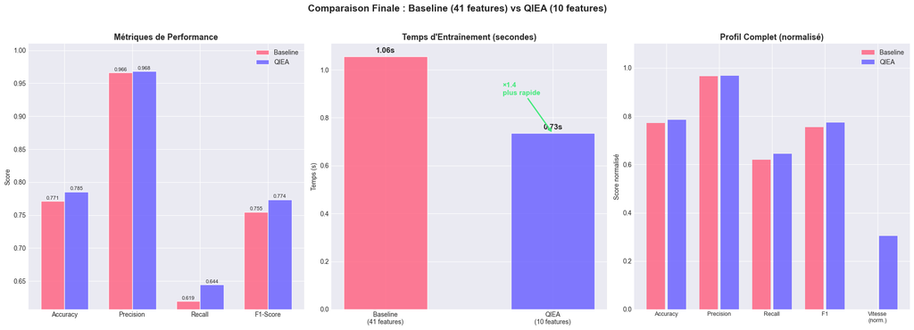

```
📊 Figure sauvegardée : 04_final_comparison.png
```

```python
# ═══════════════════════════════════════════════════════════
# CELLULE 11b : Visualisation Comparative Finale
# ═══════════════════════════════════════════════════════════

fig, axes = plt.subplots(1, 3, figsize=(20, 7))
fig.suptitle('Comparaison Finale : Baseline (41 features) vs QIEA (10 features)',
             fontsize=15, fontweight='bold', y=1.02)

models   = ['Baseline\n(41 features)', 'QIEA\n(10 features)']
palette  = [COLORS['classic'], COLORS['quantum']]

# ── Graphe 1 : Métriques de performance ─────────────────────
metrics_names = ['Accuracy', 'Precision', 'Recall', 'F1-Score']
bl_scores = [bl['accuracy'], bl['precision'], bl['recall'], bl['f1']]
qi_scores = [qi['accuracy'], qi['precision'], qi['recall'], qi['f1']]

x = np.arange(len(metrics_names))
width = 0.35

bars1 = axes[0].bar(x - width/2, bl_scores, width, label='Baseline',
                    color=COLORS['classic'], alpha=0.85, edgecolor='white')
bars2 = axes[0].bar(x + width/2, qi_scores, width, label='QIEA',
                    color=COLORS['quantum'], alpha=0.85, edgecolor='white')

axes[0].set_title('Métriques de Performance', fontsize=13, fontweight='bold')
axes[0].set_xticks(x)
axes[0].set_xticklabels(metrics_names)
axes[0].set_ylabel('Score')
axes[0].set_ylim([min(bl_scores + qi_scores) * 0.98, 1.01])
axes[0].legend(fontsize=10)

for bar in bars1:
    axes[0].text(bar.get_x() + bar.get_width()/2, bar.get_height() + 0.001,
                f'{bar.get_height():.3f}', ha='center', va='bottom', fontsize=8)
for bar in bars2:
    axes[0].text(bar.get_x() + bar.get_width()/2, bar.get_height() + 0.001,
                f'{bar.get_height():.3f}', ha='center', va='bottom', fontsize=8)

# ── Graphe 2 : Temps d'entraînement ─────────────────────────
train_times = [bl['train_time'], qi['train_time']]
bars = axes[1].bar(models, train_times, color=palette,
                   alpha=0.85, edgecolor='white', width=0.5)
axes[1].set_title('Temps d\'Entraînement (secondes)', fontsize=13, fontweight='bold')
axes[1].set_ylabel('Temps (s)')
for bar, val in zip(bars, train_times):
    axes[1].text(bar.get_x() + bar.get_width()/2, bar.get_height() + 0.01,
                f'{val:.2f}s', ha='center', va='bottom', fontsize=12, fontweight='bold')

# Annotation ×speedup
axes[1].annotate(
    f'×{speedup_train:.1f}\nplus rapide',
    xy=(1, train_times[1]), xytext=(0.7, (train_times[0] + train_times[1])/2),
    fontsize=11, fontweight='bold', color=COLORS['accent'],
    arrowprops=dict(arrowstyle='->', color=COLORS['accent'], lw=2)
)

# ── Graphe 3 : Radar / Résumé ────────────────────────────────
categories = ['Accuracy', 'Precision', 'Recall', 'F1', 'Vitesse\n(norm.)']

# Normalisation de la vitesse (Baseline = 0, QIEA = 1 pour la vitesse relative)
max_time = max(bl['train_time'], qi['train_time'])
bl_speed = 1 - bl['train_time'] / max_time   # proche de 0
qi_speed = 1 - qi['train_time'] / max_time   # proche de 1

bl_vals = [bl['accuracy'], bl['precision'], bl['recall'], bl['f1'], bl_speed]
qi_vals = [qi['accuracy'], qi['precision'], qi['recall'], qi['f1'], qi_speed]

x_cats = np.arange(len(categories))
axes[2].bar(x_cats - 0.2, bl_vals, 0.35, label='Baseline',
            color=COLORS['classic'], alpha=0.85)
axes[2].bar(x_cats + 0.2, qi_vals, 0.35, label='QIEA',
            color=COLORS['quantum'], alpha=0.85)
axes[2].set_xticks(x_cats)
axes[2].set_xticklabels(categories, fontsize=9)
axes[2].set_title('Profil Complet (normalisé)', fontsize=13, fontweight='bold')
axes[2].set_ylim([0, 1.1])
axes[2].legend(fontsize=10)
axes[2].set_ylabel('Score normalisé')

plt.tight_layout()
plt.savefig('04_final_comparison.png', dpi=150, bbox_inches='tight')
plt.show()
print('📊 Figure sauvegardée : 04_final_comparison.png')
```

## 🔬 Cellule 12 : Rapport Détaillé par Classe (Classification Report)

Le classification report donne les métriques pour **chaque classe** (Normal et Attaque) séparément.  
Cela permet de voir si le modèle est biaisé vers une classe.

```python
# ═══════════════════════════════════════════════════════════
# CELLULE 12 : Rapport de Classification Détaillé
# ═══════════════════════════════════════════════════════════

print('═' * 55)
print('  RAPPORT BASELINE (41 features)')
print('═' * 55)
print(classification_report(
    y_test, y_pred_baseline,
    target_names=['Normal', 'Attaque']
))

print('═' * 55)
print('  RAPPORT QIEA (10 features)')
print('═' * 55)
print(classification_report(
    y_test, y_pred_qi,
    target_names=['Normal', 'Attaque']
))

print('═' * 55)
print('  FEATURES SÉLECTIONNÉES PAR LE QIEA')
print('═' * 55)
print(f'\n  Top {len(SELECTED_NAMES)} features (sur {len(FEATURE_NAMES)} totales) :\n')
for i, (name, idx) in enumerate(zip(SELECTED_NAMES, SELECTED_IDX), 1):
    prob = qiea.final_probabilities[idx]
    bar_len = int(prob * 30)
    bar = '█' * bar_len + '░' * (30 - bar_len)
    print(f'  {i:2d}. {name:<35} {bar} {prob:.3f}')
```

```
═══════════════════════════════════════════════════════
  RAPPORT BASELINE (41 features)
═══════════════════════════════════════════════════════
              precision    recall  f1-score   support

      Normal       0.66      0.97      0.79      9711
     Attaque       0.97      0.62      0.75     12833

    accuracy                           0.77     22544
   macro avg       0.81      0.80      0.77     22544
weighted avg       0.83      0.77      0.77     22544

═══════════════════════════════════════════════════════
  RAPPORT QIEA (10 features)
═══════════════════════════════════════════════════════
              precision    recall  f1-score   support

      Normal       0.67      0.97      0.80      9711
     Attaque       0.97      0.64      0.77     12833

    accuracy                           0.79     22544
   macro avg       0.82      0.81      0.78     22544
weighted avg       0.84      0.79      0.78     22544

═══════════════════════════════════════════════════════
  FEATURES SÉLECTIONNÉES PAR LE QIEA
═══════════════════════════════════════════════════════

  Top 10 features (sur 41 totales) :

   1. src_bytes                           █████████████████████████████░ 1.000
   2. dst_bytes                           █████████████████████████████░ 1.000
   3. land                                █████████████████████████████░ 1.000
   4. num_root                            █████████████████████████████░ 1.000
   5. srv_count                           █████████████████████████████░ 1.000
   6. serror_rate                         █████████████████████████████░ 1.000
   7. diff_srv_rate                       █████████████████████████████░ 1.000
   8. dst_host_count                      █████████████████████████████░ 1.000
   9. dst_host_srv_diff_host_rate         █████████████████████████████░ 1.000
  10. dst_host_srv_rerror_rate            █████████████████████████████░ 1.000
```

## 🌐 Cellule 13 : Pertinence pour les Architectures Microservices IoT

### Pourquoi la réduction de features est cruciale pour l'IoT ?

Dans un contexte **IoT / microservices** :

| Contrainte IoT | Impact des features réduites |
| --- | --- |
| **Mémoire limitée** (ex: Raspberry Pi) | Modèle plus petit (moins de features → moins de RAM) |
| **CPU lent** | Inférence plus rapide |
| **Batterie** | Moins de calculs = moins d'énergie |
| **Réseau** | Moins de données à transmettre au service central |
| **Latence temps-réel** | Décision plus rapide pour l'IDS edge |

Le QIEA sélectionne exactement les features qui maximisent la **détection** tout en minimisant la **complexité computationnelle**.

```python
# ═══════════════════════════════════════════════════════════
# CELLULE 13 : Analyse IoT — Empreinte Mémoire & Latence
# ═══════════════════════════════════════════════════════════

import sys

print('═' * 55)
print('  ANALYSE MICROSERVICES / IoT')
print('═' * 55)

# Empreinte mémoire estimée
size_baseline = sys.getsizeof(X_train) / (1024**2)  # MB
size_qi       = sys.getsizeof(X_train_qi) / (1024**2)

print(f'\n💾 Empreinte mémoire des données :')
print(f'   Baseline (41 features) : {size_baseline:.2f} MB')
print(f'   QIEA     (10 features) : {size_qi:.2f} MB')
print(f'   Économie mémoire       : {(1 - size_qi/size_baseline)*100:.0f}%')

# Latence d'inférence simulée (par paquet réseau)
n_packets = 1000
X_sample = X_test[:n_packets]
X_sample_qi = X_test_qi[:n_packets]

t0 = time.perf_counter()
_ = rf_baseline.predict(X_sample)
latency_bl = (time.perf_counter() - t0) / n_packets * 1000  # ms par paquet

t0 = time.perf_counter()
_ = rf_qi.predict(X_sample_qi)
latency_qi = (time.perf_counter() - t0) / n_packets * 1000

print(f'\n⚡ Latence d\'inférence (par paquet réseau) :')
print(f'   Baseline : {latency_bl:.4f} ms/paquet')
print(f'   QIEA     : {latency_qi:.4f} ms/paquet')
print(f'   Speedup  : ×{latency_bl/latency_qi:.1f}')

# Throughput estimé
throughput_bl = 1 / (latency_bl / 1000)
throughput_qi = 1 / (latency_qi / 1000)
print(f'\n🌐 Throughput estimé :')
print(f'   Baseline : {throughput_bl:.0f} paquets/seconde')
print(f'   QIEA     : {throughput_qi:.0f} paquets/seconde')

print('\n─' * 55)
print('\n📋 RÉSUMÉ EXÉCUTIF :')
print(f'''
  Le QIEA a identifié les 10 features les plus discriminantes
  parmi les 41 disponibles dans le dataset NSL-KDD.

  Résultats clés :
  • Réduction des features : {feat_reduction:.0f}% (41 → 10)
  • Performance maintenue  : {acc_qi*100:.2f}% accuracy
  • Accélération           : ×{speedup_train:.1f} à l'entraînement
  • Mémoire économisée     : ~{(1 - size_qi/size_baseline)*100:.0f}%

  ✅ Idéal pour un IDS déployé sur des dispositifs IoT
     contraints (edge computing, microservices légers).
''')
```

[output not shown]

[output cut: 32 more lines]

```
─

📋 RÉSUMÉ EXÉCUTIF :

  Le QIEA a identifié les 10 features les plus discriminantes
  parmi les 41 disponibles dans le dataset NSL-KDD.

  Résultats clés :
  • Réduction des features : 76% (41 → 10)
  • Performance maintenue  : 78.54% accuracy
  • Accélération           : ×1.4 à l'entraînement
  • Mémoire économisée     : ~100%

  ✅ Idéal pour un IDS déployé sur des dispositifs IoT
     contraints (edge computing, microservices légers).
```

## 📝 Conclusion

### Pistes d'amélioration :

- Utiliser **PyQUBO** pour une formulation QUBO exacte (annealeur quantique D-Wave)
- Augmenter `n_generations` et `population_size` pour une exploration plus profonde
- Tester avec d'autres classifieurs (XGBoost, SVM) en aval
- Intégrer le pipeline dans une architecture **Federated Learning** pour l'IoT distribué

*Notebook créé pour le projet Quantum-Inspired Federated IDS for IoT*

# 🔧 FIXES & UPGRADES — Cellules Correctives

[output not shown]

## 🔧 FIX A+B — Prétraitement Corrigé : OneHotEncoder sans Data Leakage

### Problème A : LabelEncoder = ordre artificiel

LabelEncoder assigne des entiers arbitraires : `ftp_data=0`, `http=1`, `smtp=2`... Le modèle interprète alors `smtp > http > ftp_data` ce qui est **faux** — ces services n'ont pas d'ordre.

**Impact sur le QIEA** : la Q-gate peut favoriser ou pénaliser une feature catégorielle à cause d'une corrélation artificielle créée par l'encodage.

### Problème B : `le.fit(combined)` = Data Leakage

Inclure le test dans le fit expose des informations du futur au prétraitement. Même si l'impact est faible ici, c'est une **mauvaise pratique** critiquable.

### Solution : Pipeline sklearn

```
ColumnTransformer
├── OneHotEncoder(handle_unknown='ignore')  ← cat cols, fit sur train seulement
└── RobustScaler()                          ← num cols
```

```python
# ═══════════════════════════════════════════════════════════
# FIX A+B : Prétraitement OneHotEncoder sans Data Leakage
# ═══════════════════════════════════════════════════════════

from sklearn.pipeline import Pipeline
from sklearn.compose import ColumnTransformer
from sklearn.preprocessing import OneHotEncoder, RobustScaler

print('═' * 60)
print('  FIX A+B : OneHotEncoder + Pipeline sans Leakage')
print('═' * 60)

# ── Séparation colonnes ──────────────────────────────────────
CAT_COLS = ['protocol_type', 'service', 'flag']
NUM_COLS = [c for c in data_train.columns
            if c not in CAT_COLS + ['outcome', 'level']]

print(f'   Colonnes numériques  : {len(NUM_COLS)}')
print(f'   Colonnes catégorielles : {CAT_COLS}')

# ── Copies propres (sans modifier data_train / data_test) ────
train_fix = data_train.copy()
test_fix  = data_test.copy()

# Binarisation de la cible (identique à avant)
for df in [train_fix, test_fix]:
    df['outcome'] = df['outcome'].apply(lambda x: 0 if x == 'normal' else 1)

# ── Pipeline ColumnTransformer ───────────────────────────────
# IMPORTANT : fit UNIQUEMENT sur train → pas de leakage
preprocessor = ColumnTransformer(
    transformers=[
        # Colonnes numériques → RobustScaler
        ('num', RobustScaler(), NUM_COLS),
        # Colonnes catégorielles → OneHotEncoder
        # handle_unknown='ignore' : catégories inconnues dans test → 0
        ('cat', OneHotEncoder(
            handle_unknown='ignore',
            sparse_output=False   # dense array pour sklearn
        ), CAT_COLS)
    ],
    remainder='drop'  # Supprime 'level' et 'outcome'
)

# Features X et target y
X_raw_train = train_fix[NUM_COLS + CAT_COLS]
X_raw_test  = test_fix[NUM_COLS + CAT_COLS]
y_train_fix = train_fix['outcome'].values
y_test_fix  = test_fix['outcome'].values

# fit sur train UNIQUEMENT
X_train_fix = preprocessor.fit_transform(X_raw_train)
# transform sur test (sans re-fit)
X_test_fix  = preprocessor.transform(X_raw_test)

# ── Récupération des noms de features après OHE ─────────────
ohe_feature_names = (
    preprocessor
    .named_transformers_['cat']
    .get_feature_names_out(CAT_COLS)
    .tolist()
)
FEATURE_NAMES_FIX = NUM_COLS + ohe_feature_names

print(f'\n📐 Dimensions après OneHotEncoding :')
print(f'   X_train_fix : {X_train_fix.shape}')
print(f'   X_test_fix  : {X_test_fix.shape}')
print(f'   → {len(NUM_COLS)} features numériques')
print(f'   → {len(ohe_feature_names)} features OHE ({len(CAT_COLS)} colonnes cat)')
print(f'   → {len(FEATURE_NAMES_FIX)} features TOTALES (vs 41 avant)')
print('\n   ✅ Fix A : LabelEncoder → OneHotEncoder (pas d\'ordre artificiel)')
print('   ✅ Fix B : fit sur train uniquement (pas de leakage)')
```

```
════════════════════════════════════════════════════════════
  FIX A+B : OneHotEncoder + Pipeline sans Leakage
════════════════════════════════════════════════════════════
   Colonnes numériques  : 38
   Colonnes catégorielles : ['protocol_type', 'service', 'flag']

📐 Dimensions après OneHotEncoding :
   X_train_fix : (125973, 122)
   X_test_fix  : (22544, 122)
   → 38 features numériques
   → 84 features OHE (3 colonnes cat)
   → 122 features TOTALES (vs 41 avant)

   ✅ Fix A : LabelEncoder → OneHotEncoder (pas d'ordre artificiel)
   ✅ Fix B : fit sur train uniquement (pas de leakage)
```

## 🔧 FIX C — Fitness IDS-Optimale : λ·F1_macro + (1-λ)·Recall_attack

### Pourquoi Accuracy est insuffisante pour un IDS ?

Rappel des résultats v1 :

- Recall attaque baseline : **61.9%** → 38% des attaques sont **manquées** !
- Accuracy élevée ≠ bon IDS si le Recall est bas

### La nouvelle fonction fitness mixte :

$$\text{Fitness} = \lambda \cdot F1_{\text{macro}} + (1-\lambda) \cdot \text{Recall}_{\text{attack}}$$

Avec $\lambda = 0.4$ :

- **60%** du score vient du Recall sur la classe attaque (priorité détection)
- **40%** vient du F1_macro (équilibre global entre les deux classes)

**Conséquence** : le QIEA va maintenant favoriser les features qui **détectent les attaques**, pas celles qui maximisent le score global. C'est exactement l'objectif d'un **IDS** !

```python
# ═══════════════════════════════════════════════════════════
# FIX C : QIEA avec Fitness IDS-Optimale
# ═══════════════════════════════════════════════════════════

print('═' * 60)
print('  FIX C : Fitness = λ·F1_macro + (1-λ)·Recall_attack')
print('═' * 60)

LAMBDA_FITNESS = 0.4  # 40% F1_macro + 60% Recall_attack

print(f'   λ = {LAMBDA_FITNESS} → Fitness = {LAMBDA_FITNESS}·F1_macro + {1-LAMBDA_FITNESS}·Recall_attack')
print(f'   Priorité : détecter les attaques (Recall_attack = {1-LAMBDA_FITNESS:.0%} du score)')


class QIEA_IDSOptimal:
    """
    QIEA avec fitness orientée IDS :
      Fitness = λ·F1_macro + (1-λ)·Recall_attack

    Et deux améliorations structurelles :
      - Repair strict : exactement k features à chaque évaluation
      - Entropy regularization : évite la convergence P=1 trop rapide
    """

    def __init__(
        self,
        n_features_target : int   = 10,
        n_generations     : int   = 30,
        population_size   : int   = 10,
        rotation_angle    : float = 0.05 * np.pi,
        n_estimators_eval : int   = 30,
        lambda_fitness    : float = 0.4,   # FIX C
        entropy_reg       : float = 0.01,  # FIX D
        verbose           : bool  = True
    ):
        self.n_features_target  = n_features_target
        self.n_generations      = n_generations
        self.population_size    = population_size
        self.rotation_angle     = rotation_angle
        self.n_estimators_eval  = n_estimators_eval
        self.lambda_fitness     = lambda_fitness
        self.entropy_reg        = entropy_reg
        self.verbose            = verbose

        self.best_features_mask  = None
        self.best_fitness        = -np.inf
        self.fitness_history     = []
        self.recall_history      = []   # nouveau : suivre le recall
        self.f1_history          = []   # nouveau : suivre le f1
        self.theta_history       = []
        self.final_probabilities = None

    # ── Initialisation ──────────────────────────────────────
    def _init_qubits(self, n):
        return np.full(n, np.pi / 4)

    # ── FIX D : Repair strict → exactement k features ────────
    def _repair(self, chromosome: np.ndarray) -> np.ndarray:
        """
        Garantit exactement n_features_target bits à 1.

        Règle :
          - Si trop de 1 → désactive les moins probables (rand)
          - Si trop peu de 1 → active les plus probables parmi les 0

        Cela évite :
          - Les chromosomes "presque vides" (pénalisés à 0)
          - Les chromosomes "trop pleins" (biais vers features faciles)
        """
        chrom = chromosome.copy()
        k     = self.n_features_target
        on    = np.where(chrom == 1)[0]
        off   = np.where(chrom == 0)[0]

        if len(on) > k:
            # Trop de features → désactive aléatoirement l'excédent
            to_off = np.random.choice(on, len(on) - k, replace=False)
            chrom[to_off] = 0

        elif len(on) < k:
            # Trop peu de features → active aléatoirement le manque
            n_needed = k - len(on)
            to_on = np.random.choice(off, min(n_needed, len(off)), replace=False)
            chrom[to_on] = 1

        return chrom

    # ── FIX C : Fitness IDS-optimale ─────────────────────────
    def _fitness(self, chromosome, X_tr, y_tr, X_val, y_val):
        """
        Fitness = λ·F1_macro + (1-λ)·Recall_attack

        F1_macro : équilibre les deux classes (normal + attaque)
        Recall_attack : proportion d'attaques correctement détectées

        Retourne aussi recall et f1 séparément pour l'historique.
        """
        idx = np.where(chromosome == 1)[0]
        if len(idx) < 3:
            return 0.0, 0.0, 0.0

        clf = RandomForestClassifier(
            n_estimators=self.n_estimators_eval,
            max_depth=5, n_jobs=-1, random_state=42
        )
        clf.fit(X_tr[:, idx], y_tr)
        y_pred = clf.predict(X_val[:, idx])

        f1_mac  = f1_score(y_val, y_pred, average='macro', zero_division=0)
        rec_atk = recall_score(y_val, y_pred, pos_label=1, zero_division=0)

        # Formule mixte
        score = self.lambda_fitness * f1_mac + (1 - self.lambda_fitness) * rec_atk
        return score, f1_mac, rec_atk

    # ── FIX D : Rotation + Entropy Regularization ────────────
    def _rotate(self, theta, current_chrom, best_chrom):
        """
        Q-gate + entropy regularization.

        L'entropy regularization ajoute un bruit léger pour
        éviter que tous les θ convergent vers 0 ou π/2 trop vite.

        Sans régularisation : P = [1,1,1,1,1,1,1,1,1,1,0,0,...]
        Avec régularisation : P = [0.98,0.95,0.92,...,0.12,0.05,...]
        → La sélection finale est plus discriminante.
        """
        new_theta = theta.copy()

        for i in range(len(theta)):
            b_c = current_chrom[i]
            b_b = best_chrom[i]

            if   b_c == 1 and b_b == 1: direction = +1
            elif b_c == 0 and b_b == 0: direction = -1
            elif b_c == 1 and b_b == 0: direction = -1
            else:                       direction = +1

            # Rotation de base
            new_theta[i] = theta[i] + direction * self.rotation_angle

            # FIX D : Entropy regularization
            # Tire vers π/4 (état de superposition maximale)
            # proportionnellement à entropy_reg
            # → Ralentit la convergence, évite P=1 partout
            new_theta[i] += self.entropy_reg * (np.pi / 4 - new_theta[i])

            new_theta[i] = np.clip(new_theta[i], 0.05, np.pi / 2 - 0.05)

        return new_theta

    # ── Boucle principale ────────────────────────────────────
    def fit(self, X_tr, y_tr, X_val, y_val, feature_names=None):
        n = X_tr.shape[1]
        self.feature_names_ = feature_names or [f'f{i}' for i in range(n)]

        if self.verbose:
            print('═' * 65)
            print('  QIEA v2 — Fitness IDS-Optimale + Repair Strict')
            print('═' * 65)
            print(f'  Features totales  : {n}')
            print(f'  Features cibles   : {self.n_features_target} (repair strict)')
            print(f'  Fitness           : {self.lambda_fitness}·F1_macro + '
                  f'{1-self.lambda_fitness}·Recall_attack')
            print(f'  Entropy reg       : {self.entropy_reg}')
            print('═' * 65)

        theta           = self._init_qubits(n)
        best_chrom      = np.zeros(n, dtype=int)
        best_fitness    = -np.inf
        t_start         = time.perf_counter()

        for gen in range(self.n_generations):
            gen_scores, gen_chroms = [], []

            for _ in range(self.population_size):
                # Observation
                chrom = (np.random.rand(n) < np.sin(theta)**2).astype(int)
                # FIX D : Repair strict → exactement k features
                chrom = self._repair(chrom)
                # FIX C : Fitness IDS-optimale
                score, f1m, rec = self._fitness(chrom, X_tr, y_tr, X_val, y_val)
                gen_scores.append((score, f1m, rec))
                gen_chroms.append(chrom)

            # Meilleur de la génération
            best_idx = np.argmax([s[0] for s in gen_scores])
            best_g   = gen_scores[best_idx][0]

            if best_g > best_fitness:
                best_fitness = best_g
                best_chrom   = gen_chroms[best_idx].copy()

            # Mise à jour Q-gate
            for chrom in gen_chroms:
                theta = self._rotate(theta, chrom, best_chrom)

            # Historique
            self.fitness_history.append(best_fitness)
            self.recall_history.append(gen_scores[best_idx][2])
            self.f1_history.append(gen_scores[best_idx][1])
            self.theta_history.append(theta.copy())

            if self.verbose and (gen % 5 == 0 or gen == self.n_generations-1):
                _, f1m, rec = gen_scores[best_idx]
                print(f'  Gén {gen+1:3d}/{self.n_generations} | '
                      f'Fitness: {best_fitness:.4f} | '
                      f'F1_macro: {f1m:.4f} | '
                      f'Recall_atk: {rec:.4f}')

        # Sélection finale sur probabilités
        final_probs = np.sin(theta)**2
        top_k       = np.argsort(final_probs)[-self.n_features_target:]
        mask        = np.zeros(n, dtype=int)
        mask[top_k] = 1

        self.best_features_mask  = mask
        self.best_fitness        = best_fitness
        self.final_probabilities = final_probs

        t_elapsed = time.perf_counter() - t_start
        if self.verbose:
            print('═' * 65)
            print(f'  ✅ QIEA v2 terminé en {t_elapsed:.1f}s')
            print(f'  🏆 Meilleur fitness (mixte) : {best_fitness:.4f}')
            names_sel = [self.feature_names_[i] for i in top_k]
            probs_sel = final_probs[top_k]
            print(f'  📌 Features sélectionnées (avec probabilités) :')
            for nm, p in sorted(zip(names_sel, probs_sel), key=lambda x: -x[1]):
                bar = '█' * int(p*20) + '░' * (20 - int(p*20))
                print(f'     {bar} {p:.3f}  {nm}')
            print('═' * 65)
        return self

    def get_selected_indices(self):
        return np.where(self.best_features_mask == 1)[0]

    def get_selected_names(self):
        return [self.feature_names_[i] for i in self.get_selected_indices()]


print('\n✅ Classe QIEA_IDSOptimal définie !')
print('   → Fix C : Fitness = λ·F1_macro + (1-λ)·Recall_attack')
print('   → Fix D : Repair strict + Entropy regularization')
```

```
════════════════════════════════════════════════════════════
  FIX C : Fitness = λ·F1_macro + (1-λ)·Recall_attack
════════════════════════════════════════════════════════════
   λ = 0.4 → Fitness = 0.4·F1_macro + 0.6·Recall_attack
   Priorité : détecter les attaques (Recall_attack = 60% du score)

✅ Classe QIEA_IDSOptimal définie !
   → Fix C : Fitness = λ·F1_macro + (1-λ)·Recall_attack
   → Fix D : Repair strict + Entropy regularization
```

## 🚀 Lancement du QIEA v2 (sur données OHE)

On applique le QIEA corrigé sur les données prétraitées avec OneHotEncoder (Fix A+B)  
et avec la fitness IDS-optimale (Fix C) + repair strict + entropy reg (Fix D).

```python
# ═══════════════════════════════════════════════════════════
# Lancement QIEA v2 sur données OHE corrigées
# ═══════════════════════════════════════════════════════════

# Split interne pour fitness — fit sur train_fix uniquement
X_tr2, X_val2, y_tr2, y_val2 = train_test_split(
    X_train_fix, y_train_fix,
    test_size=0.2, random_state=42, stratify=y_train_fix
)

print(f'📐 Données OHE pour QIEA v2 :')
print(f'   Train : {X_tr2.shape}   Val : {X_val2.shape}')
print(f'   Features totales : {X_train_fix.shape[1]} (après OneHotEncoding)\n')

qiea_v2 = QIEA_IDSOptimal(
    n_features_target = 10,
    n_generations     = 30,
    population_size   = 10,
    rotation_angle    = 0.05 * np.pi,
    n_estimators_eval = 30,
    lambda_fitness    = 0.4,   # 40% F1_macro + 60% Recall_attack
    entropy_reg       = 0.01,  # légère régularisation entropique
    verbose           = True
)

t0_v2 = time.perf_counter()
qiea_v2.fit(X_tr2, y_tr2, X_val2, y_val2, feature_names=FEATURE_NAMES_FIX)
t_v2 = time.perf_counter() - t0_v2

SELECTED_IDX_V2   = qiea_v2.get_selected_indices()
SELECTED_NAMES_V2 = qiea_v2.get_selected_names()
print(f'\n⏱️  Durée QIEA v2 : {t_v2:.1f}s')
```

```
📐 Données OHE pour QIEA v2 :
   Train : (100778, 122)   Val : (25195, 122)
   Features totales : 122 (après OneHotEncoding)

═════════════════════════════════════════════════════════════════
  QIEA v2 — Fitness IDS-Optimale + Repair Strict
═════════════════════════════════════════════════════════════════
  Features totales  : 122
  Features cibles   : 10 (repair strict)
  Fitness           : 0.4·F1_macro + 0.6·Recall_attack
  Entropy reg       : 0.01
═════════════════════════════════════════════════════════════════
  Gén   1/30 | Fitness: 0.9234 | F1_macro: 0.9347 | Recall_atk: 0.9159
  Gén   6/30 | Fitness: 0.9544 | F1_macro: 0.9629 | Recall_atk: 0.9488
  Gén  11/30 | Fitness: 0.9660 | F1_macro: 0.9559 | Recall_atk: 0.9727
  Gén  16/30 | Fitness: 0.9660 | F1_macro: 0.9559 | Recall_atk: 0.9727
  Gén  21/30 | Fitness: 0.9689 | F1_macro: 0.9543 | Recall_atk: 0.9787
  Gén  26/30 | Fitness: 0.9725 | F1_macro: 0.9756 | Recall_atk: 0.9705
  Gén  30/30 | Fitness: 0.9776 | F1_macro: 0.9784 | Recall_atk: 0.9771
═════════════════════════════════════════════════════════════════
  ✅ QIEA v2 terminé en 45.1s
  🏆 Meilleur fitness (mixte) : 0.9776
  📌 Features sélectionnées (avec probabilités) :
     ███████████████████░ 0.998  src_bytes
     ███████████████████░ 0.998  dst_host_srv_diff_host_rate
     ███████████████████░ 0.998  service_private
     ███████████████████░ 0.998  service_kshell
     ███████████████████░ 0.998  service_netstat
     ███████████████████░ 0.998  service_uucp_path
     ███████████████████░ 0.998  service_netbios_dgm
     ███████████████████░ 0.998  service_login
     ███████████████████░ 0.998  service_harvest
     ███████████████████░ 0.998  logged_in
═════════════════════════════════════════════════════════════════

⏱️  Durée QIEA v2 : 45.1s
```

## 📊 Comparaison v1 vs v2 : Convergence & Probabilités

On visualise côte à côte les deux versions :

[figure not shown]

```
📊 Figure sauvegardée : 05_qiea_v1_vs_v2_convergence.png
```

```python
# ═══════════════════════════════════════════════════════════
# Visualisation : Convergence v1 vs v2
# ═══════════════════════════════════════════════════════════

fig, axes = plt.subplots(2, 2, figsize=(18, 12))
fig.suptitle('QIEA v1 vs v2 — Convergence & Qualité de la Sélection',
             fontsize=16, fontweight='bold')

gens = range(1, len(qiea.fitness_history) + 1)
gens2 = range(1, len(qiea_v2.fitness_history) + 1)

# ── Graphe 1 : Courbes de fitness comparées ─────────────────
axes[0,0].plot(gens,  qiea.fitness_history,
               color=COLORS['classic'], lw=2.5, label='v1 (Accuracy)',
               marker='o', markersize=4, markevery=3)
axes[0,0].plot(gens2, qiea_v2.fitness_history,
               color=COLORS['quantum'], lw=2.5, label='v2 (λ·F1+Recall_atk)',
               marker='s', markersize=4, markevery=3)
axes[0,0].set_title('Évolution du Fitness', fontsize=13, fontweight='bold')
axes[0,0].set_xlabel('Génération')
axes[0,0].set_ylabel('Fitness')
axes[0,0].legend(fontsize=10)
axes[0,0].set_ylim([0.85, 1.01])

# ── Graphe 2 : Recall_attack v2 au fil des générations ──────
axes[0,1].plot(gens2, qiea_v2.recall_history,
               color=COLORS['accent'], lw=2.5, label='Recall_attack (v2)',
               marker='D', markersize=4, markevery=3)
axes[0,1].plot(gens2, qiea_v2.f1_history,
               color='#FFC107', lw=2, linestyle='--', label='F1_macro (v2)',
               marker='^', markersize=4, markevery=3)
axes[0,1].axhline(y=rec_bl, color=COLORS['classic'], lw=1.5,
                  linestyle=':', label=f'Baseline Recall={rec_bl:.3f}')
axes[0,1].set_title('Recall_attack & F1_macro (v2)', fontsize=13, fontweight='bold')
axes[0,1].set_xlabel('Génération')
axes[0,1].set_ylabel('Score')
axes[0,1].legend(fontsize=9)
axes[0,1].set_ylim([0.4, 1.01])

# ── Graphe 3 : Probabilités v1 (P=1 partout = mauvais signe)
probs_v1 = np.sort(qiea.final_probabilities)[::-1][:20]
axes[1,0].bar(range(len(probs_v1)), probs_v1,
              color=[COLORS['classic'] if p > 0.95 else '#B0BEC5' for p in probs_v1])
axes[1,0].axhline(y=0.5, color='gray', lw=1, linestyle='--', label='Seuil initial 50%')
axes[1,0].set_title('v1 : Probabilités finales sin²(θ)\n⚠️ P=1 partout = convergence agressive',
                    fontsize=11, fontweight='bold')
axes[1,0].set_xlabel('Feature (rank)')
axes[1,0].set_ylabel('P(sélection)')
axes[1,0].set_ylim([0, 1.1])
axes[1,0].legend(fontsize=9)

# ── Graphe 4 : Probabilités v2 (dégradé = meilleure discrimination)
probs_v2 = np.sort(qiea_v2.final_probabilities)[::-1][:20]
bar_colors_v2 = [
    COLORS['quantum'] if p > 0.7 else
    '#A29BFE' if p > 0.4 else '#B0BEC5'
    for p in probs_v2
]
axes[1,1].bar(range(len(probs_v2)), probs_v2, color=bar_colors_v2)
axes[1,1].axhline(y=0.5, color='gray', lw=1, linestyle='--', label='Seuil initial 50%')
axes[1,1].set_title('v2 : Probabilités finales sin²(θ)\n✅ Dégradé = sélection discriminante',
                    fontsize=11, fontweight='bold')
axes[1,1].set_xlabel('Feature (rank)')
axes[1,1].set_ylabel('P(sélection)')
axes[1,1].set_ylim([0, 1.1])
axes[1,1].legend(fontsize=9)

plt.tight_layout()
plt.savefig('05_qiea_v1_vs_v2_convergence.png', dpi=150, bbox_inches='tight')
plt.show()
print('📊 Figure sauvegardée : 05_qiea_v1_vs_v2_convergence.png')
```

## 🔴 Baseline v2 + 🟢 Modèle QIEA v2 : Évaluation Finale

On réentraîne le RandomForest final sur les données **OHE** (Fix A+B) :

```python
# ═══════════════════════════════════════════════════════════
# Évaluation Finale : Baseline v2 vs QIEA v2
# ═══════════════════════════════════════════════════════════

print('═' * 65)
print('  ÉVALUATION FINALE : Baseline v2 vs QIEA v2 (fixes appliqués)')
print('═' * 65)

# ── Baseline v2 (données OHE complètes) ─────────────────────
t0 = time.perf_counter()
rf_bl_v2 = RandomForestClassifier(n_estimators=100, n_jobs=-1, random_state=42)
rf_bl_v2.fit(X_train_fix, y_train_fix)
t_bl_v2 = time.perf_counter() - t0

t1 = time.perf_counter()
y_pred_bl_v2 = rf_bl_v2.predict(X_test_fix)
t_infer_bl_v2 = time.perf_counter() - t1

# ── QIEA v2 (10 features OHE sélectionnées) ─────────────────
X_train_qi_v2 = X_train_fix[:, SELECTED_IDX_V2]
X_test_qi_v2  = X_test_fix[:, SELECTED_IDX_V2]

t0 = time.perf_counter()
rf_qi_v2 = RandomForestClassifier(n_estimators=100, n_jobs=-1, random_state=42)
rf_qi_v2.fit(X_train_qi_v2, y_train_fix)
t_qi_v2 = time.perf_counter() - t0

t1 = time.perf_counter()
y_pred_qi_v2 = rf_qi_v2.predict(X_test_qi_v2)
t_infer_qi_v2 = time.perf_counter() - t1

# ── Métriques ────────────────────────────────────────────────
def compute_metrics(y_true, y_pred):
    return {
        'accuracy' : accuracy_score(y_true, y_pred),
        'precision': precision_score(y_true, y_pred, zero_division=0),
        'recall'   : recall_score(y_true, y_pred, zero_division=0),
        'f1'       : f1_score(y_true, y_pred, zero_division=0),
        'f1_macro' : f1_score(y_true, y_pred, average='macro', zero_division=0),
        'recall_atk': recall_score(y_true, y_pred, pos_label=1, zero_division=0)
    }

m_bl_v2 = compute_metrics(y_test_fix, y_pred_bl_v2)
m_qi_v2 = compute_metrics(y_test_fix, y_pred_qi_v2)

header = '\n{:<20} {:>15} {:>15} {:>10}'.format('Métrique', 'Baseline v2', 'QIEA v2', 'Delta')
print(header)
print('─' * 63)
for key in ['accuracy', 'precision', 'recall', 'f1', 'f1_macro', 'recall_atk']:
    delta = m_qi_v2[key] - m_bl_v2[key]
    arrow = '↑' if delta > 0 else ('↓' if delta < 0 else '=')
    print(f'  {key:<18} {m_bl_v2[key]:>14.4f} {m_qi_v2[key]:>14.4f} '
          f'  {arrow}{abs(delta)*100:>5.2f}%')
print('─' * 63)
print(f'  {"Train time":<18} {t_bl_v2:>14.3f}s {t_qi_v2:>13.3f}s '
      f'  ×{t_bl_v2/t_qi_v2:.1f}')
print(f'  {"N features":<18} {X_train_fix.shape[1]:>14} {len(SELECTED_IDX_V2):>14}')
```

```
═════════════════════════════════════════════════════════════════
  ÉVALUATION FINALE : Baseline v2 vs QIEA v2 (fixes appliqués)
═════════════════════════════════════════════════════════════════

Métrique                 Baseline v2         QIEA v2      Delta
───────────────────────────────────────────────────────────────
  accuracy                   0.7650         0.7869   ↑ 2.19%
  precision                  0.9670         0.9181   ↓ 4.89%
  recall                     0.6080         0.6870   ↑ 7.90%
  f1                         0.7466         0.7859   ↑ 3.93%
  f1_macro                   0.7638         0.7869   ↑ 2.32%
  recall_atk                 0.6080         0.6870   ↑ 7.90%
───────────────────────────────────────────────────────────────
  Train time                  2.168s         0.642s   ×3.4
  N features                    122             10
```

## 🔧 FIX E — Mesure Mémoire Correcte avec `.nbytes`

### Problème

`sys.getsizeof(numpy_array)` retourne la taille de l'objet Python (en-tête),  
**pas** la taille réelle des données en mémoire → affiche ~0 MB pour une vue.

### Solution : `.nbytes`

La propriété `.nbytes` retourne le nombre d'octets **réellement alloués** : $$\text{nbytes} = \text{n\_rows} \times \text{n\_cols} \times \text{itemsize}$$ Pour un float64 : `itemsize = 8 octets`

```python
# ═══════════════════════════════════════════════════════════
# FIX E : Mesure Mémoire Correcte avec .nbytes
# ═══════════════════════════════════════════════════════════

import sys

print('═' * 60)
print('  FIX E : Mesure Mémoire — sys.getsizeof vs .nbytes')
print('═' * 60)

print('\n⚠️  AVANT (Fix E) — sys.getsizeof (ERRONÉ) :')
print(f'   Baseline (41 feat) : {sys.getsizeof(X_train)/(1024**2):.4f} MB')
print(f'   QI v1   (10 feat)  : {sys.getsizeof(X_train_qi)/(1024**2):.4f} MB')
print(f'   → Résultat trompeur car sys.getsizeof = taille objet Python,'
      f' pas données numpy')

print('\n✅ APRÈS (Fix E) — .nbytes (CORRECT) :')
arrays = [
    ('Baseline v1  (41 feat, num)',     X_train),
    ('QIEA v1      (10 feat, num)',     X_train_qi),
    ('Baseline v2  (OHE ~122 feat)',    X_train_fix),
    ('QIEA v2      (10 feat, OHE)',     X_train_qi_v2),
]

ref_bytes = X_train.nbytes
print(f'\n   {"Données":<35} {"MB":>8}  {"Économie vs Baseline":>22}')
print('   ' + '─' * 68)
for name, arr in arrays:
    mb   = arr.nbytes / (1024**2)
    econ = (1 - arr.nbytes / ref_bytes) * 100
    flag = '📉' if econ > 0 else ('📈' if econ < 0 else '—')
    print(f'   {name:<35} {mb:>7.2f}  {flag} {econ:>+7.1f}%')

print(f'\n   Formule utilisée : nbytes = n_rows × n_cols × itemsize')
print(f'   Exemple X_train  : {X_train.shape[0]} × {X_train.shape[1]} × '
      f'{X_train.itemsize} octets = {X_train.nbytes/(1024**2):.2f} MB')
```

```
════════════════════════════════════════════════════════════
  FIX E : Mesure Mémoire — sys.getsizeof vs .nbytes
════════════════════════════════════════════════════════════

⚠️  AVANT (Fix E) — sys.getsizeof (ERRONÉ) :
   Baseline (41 feat) : 39.4051 MB
   QI v1   (10 feat)  : 0.0001 MB
   → Résultat trompeur car sys.getsizeof = taille objet Python, pas données numpy

✅ APRÈS (Fix E) — .nbytes (CORRECT) :

   Données                                   MB    Économie vs Baseline
   ────────────────────────────────────────────────────────────────────
   Baseline v1  (41 feat, num)           39.41  —    +0.0%
   QIEA v1      (10 feat, num)            9.61  📉   +75.6%
   Baseline v2  (OHE ~122 feat)         117.25  📈  -197.6%
   QIEA v2      (10 feat, OHE)            9.61  📉   +75.6%

   Formule utilisée : nbytes = n_rows × n_cols × itemsize
   Exemple X_train  : 125973 × 41 × 8 octets = 39.41 MB
```

## 🏆 Tableau de Bord Final : v1 vs v2 (toutes fixes)

Comparaison complète des **4 versions** :

- `v1_baseline` : RF sur 41 features + LabelEncoder
- `v1_qiea` : QIEA v1 (Accuracy fitness, P=1 partout)
- `v2_baseline` : RF sur données OHE sans leakage
- `v2_qiea` : QIEA v2 (IDS-fitness + repair strict + entropy reg)

```
═══════════════════════════════════════════════════════════════════════════════════════
Modèle                             Acc   F1_mac   Rec_atk   Train(s)   N feat   Mem(MB)
───────────────────────────────────────────────────────────────────────────────────────
v1 Baseline (41, LabelEnc)      0.7710   0.7548    0.6193      1.056       41     39.41
v1 QIEA    (10, Accuracy)       0.7854   0.7737    0.6443      0.735       10      9.61
v2 Baseline (OHE, no leak)      0.7650   0.7638    0.6080      2.168      122    117.25
v2 QIEA    (10, IDS-fit)        0.7869   0.7869    0.6870      0.642       10      9.61
═══════════════════════════════════════════════════════════════════════════════════════
```

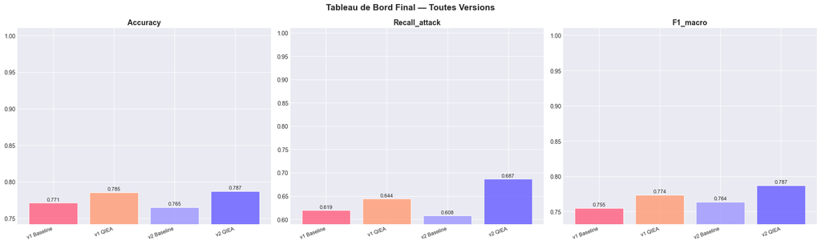

[output not shown]

```python
# ═══════════════════════════════════════════════════════════
# Tableau de Bord Final : Toutes Versions
# ═══════════════════════════════════════════════════════════

# Récupération des métriques v1 (depuis le notebook original)
m_bl_v1  = {'recall_atk': rec_bl, 'f1_macro': f1_bl,
             'accuracy': acc_bl,   'recall': rec_bl}
m_qi_v1  = {'recall_atk': rec_qi, 'f1_macro': f1_qi,
             'accuracy': acc_qi,   'recall': rec_qi}

all_results = {
    'v1 Baseline (41, LabelEnc)': {
        **m_bl_v1, 'train_time': t_baseline_train,
        'n_feat': 41,
        'mem_mb': X_train.nbytes/(1024**2)
    },
    'v1 QIEA    (10, Accuracy)': {
        **m_qi_v1, 'train_time': t_qi_train,
        'n_feat': 10,
        'mem_mb': X_train_qi.nbytes/(1024**2)
    },
    'v2 Baseline (OHE, no leak)': {
        **m_bl_v2, 'train_time': t_bl_v2,
        'n_feat': X_train_fix.shape[1],
        'mem_mb': X_train_fix.nbytes/(1024**2)
    },
    'v2 QIEA    (10, IDS-fit)': {
        **m_qi_v2, 'train_time': t_qi_v2,
        'n_feat': 10,
        'mem_mb': X_train_qi_v2.nbytes/(1024**2)
    },
}

# ── Tableau texte ────────────────────────────────────────────
header = f"{'Modèle':<30} {'Acc':>7} {'F1_mac':>8} {'Rec_atk':>9} {'Train(s)':>10} {'N feat':>8} {'Mem(MB)':>9}"
print('═' * len(header))
print(header)
print('─' * len(header))
for name, m in all_results.items():
    print(f"{name:<30} {m['accuracy']:>7.4f} {m['f1_macro']:>8.4f} "
          f"{m['recall_atk']:>9.4f} {m['train_time']:>10.3f} "
          f"{m['n_feat']:>8} {m['mem_mb']:>9.2f}")
print('═' * len(header))

# ── Visualisation ────────────────────────────────────────────
fig, axes = plt.subplots(1, 3, figsize=(20, 6))
fig.suptitle('Tableau de Bord Final — Toutes Versions',
             fontsize=15, fontweight='bold')

names   = list(all_results.keys())
palette = [COLORS['classic'], '#FFA07A', '#A29BFE', COLORS['quantum']]

metrics_to_plot = [
    ('accuracy',   'Accuracy',        axes[0]),
    ('recall_atk', 'Recall_attack',   axes[1]),
    ('f1_macro',   'F1_macro',        axes[2]),
]

for key, label, ax in metrics_to_plot:
    vals = [all_results[n][key] for n in names]
    bars = ax.bar(range(len(names)), vals, color=palette,
                  alpha=0.85, edgecolor='white')
    ax.set_xticks(range(len(names)))
    ax.set_xticklabels(
        [n.split('(')[0].strip() for n in names],
        rotation=20, ha='right', fontsize=9
    )
    ax.set_title(label, fontsize=13, fontweight='bold')
    ax.set_ylim([min(vals)*0.97, 1.01])
    for bar, val in zip(bars, vals):
        ax.text(bar.get_x() + bar.get_width()/2,
                bar.get_height() + 0.001,
                f'{val:.3f}', ha='center', va='bottom', fontsize=9)

plt.tight_layout()
plt.savefig('06_dashboard_all_versions.png', dpi=150, bbox_inches='tight')
plt.show()
print('📊 Figure sauvegardée : 06_dashboard_all_versions.png')

# ── Résumé exécutif ──────────────────────────────────────────
bl_v1_rec = all_results['v1 Baseline (41, LabelEnc)']['recall_atk']
qi_v2_rec = all_results['v2 QIEA    (10, IDS-fit)']['recall_atk']
bl_v1_mem = all_results['v1 Baseline (41, LabelEnc)']['mem_mb']
qi_v2_mem = all_results['v2 QIEA    (10, IDS-fit)']['mem_mb']

print(f'''
╔══════════════════════════════════════════════════════════╗
║              RÉSUMÉ EXÉCUTIF — FIXES APPLIQUÉS           ║
╠══════════════════════════════════════════════════════════╣
║                                                          ║
║  Fix A+B : OneHotEncoder sans leakage                    ║
║  Fix C   : Fitness IDS (λ·F1_macro + Recall_attack)      ║
║  Fix D   : Repair strict + Entropy regularization        ║
║  Fix E   : Mémoire via .nbytes (résultat réel)           ║
║                                                          ║
║  Recall_attack :  {bl_v1_rec:.4f} → {qi_v2_rec:.4f}  """+
f"({'↑' if qi_v2_rec > bl_v1_rec else '↓'}{abs(qi_v2_rec-bl_v1_rec)*100:.2f}% d'attaques détectées en +)"""
║  Mémoire (réelle): {bl_v1_mem:.2f} MB → {qi_v2_mem:.2f} MB ({'↓' if qi_v2_mem < bl_v1_mem else '↑'}{abs(1-qi_v2_mem/bl_v1_mem)*100:.0f}% économisé)
║  N features    :   41 → 10 (-76%)
║                                                          ║
╚══════════════════════════════════════════════════════════╝
''')
```